# SourceMeter 8.2 for C/C++

# Introduction

FrontEndART SourceMeter for C/C++ is a source code analyzer tool, which can perform deep static analysis of the source code of complex C/C++ systems (https://www.sourcemeter.com).

The source code of a program is usually its only up-to-date documentation. At the same time, the source code is the exquisite bearer of knowledge, business processes and methodology, accumulated over a long period of time. Source code quality decrease, which happens due to many quick fixes and time pressure, results in the increase of development and testing costs, and operational risks. In spite of this, the source code usually receives hostile treatment and is merely considered as a tool.

FrontEndART has developed SourceMeter based on the Columbus technology researched and developed at the [Department of Software Engineering](http://www.sed.inf.u-szeged.hu/softwarequality) of the University of Szeged. SourceMeter provides deep static analysis of source code. Using the results of the analysis, the quality of the analyzed source code can be improved and developed both in the short- and long term in a directed way.

All features of SourceMeter for C/C++ are free, except the FaultHunter module. Additionally, in the free version the number of metrics is limited to 14.

## Product characteristics

The most important product characteristics of FrontEndART SourceMeter are the following:

- Platform-independent command line tools
- Transparent integration into build processes
- Powerful filter management
- Coding issue detection:
  - Common programming mistakes (FaultHunter module)
  - Metric threshold violations (MetricHunter module)
  - [Cppcheck](http://cppcheck.sourceforge.net/) 1.68 coding rule violations
- Clone detection (copy-pasted source code fragments) extended with clone tracking and “clone smells”
  - Syntax-based, so-called Type-2 clones
- Metrics calculation at component, file, namespace, class, function and method levels:
  - Source code metrics
  - Clone metrics
  - Coding rule violation metrics

By continuous static analysis, the software developers can:

- reduce the software erosion rate and this way decrease development costs;
- coding problems can be identified before testing, so the number of test iterations and the testing costs can be reduced;
- the number of errors in delivered software can be reduced, so the operational risks can be decreased, increasing the company’s reputation.

SourceMeter supports the C++ language defined by the ISO/IEC 14882:2011 international standard extended with several new features from ISO/IEC 14882:2014, and C language defined by the ANSI/ISO 9899:1990, ISO/IEC 9899:1999 and ISO/IEC 9899:2011 standards. Besides the standard features, several GCC and Microsoft specific extensions are also supported.

SourceMeter uses a so-called compiler wrapping technique during source code analysis, which means that the code analysis is performed in parallel with the usual build process transparently, by wrapping the calls to the compiler. These is no need to modify the source code or the build system. The analysis results will reflect the actual build configuration of the analyzed system.

With the help of the filtering mechanism it is possible to specify a certain part of the ASG to be used (or not to be used) during the analysis, hence the results can be made more focused and the usage of memory and CPU can be reduced (e.g. generated source files or test code can be filtered out).

Visit our corporate website at http://www.frontendart.com to find the latest information about SourceMeter and read more about related products and services. Note, that if you are using only the free features of SourceMeter, we do not provide any free support for it. However, FrontEndART offers support services, so please feel free to search for solutions to your problems on our website and contact us with any questions you might have. We welcome feedback about the usability and eventual issues of the tool and further development suggestions at .

## Background

During the static analysis, an Abstract Semantic Graph (ASG) is constructed from the language elements of the source code. This ASG is then processed by the different tools in the package to calculate product metrics, identify copy-pasted code (clones), coding rule violations, etc.

# Installation

## Supported platforms

SourceMeter supports the following x86 and x86-64 platforms:

- Microsoft Windows 7, 8, 8.1, and 10
- Microsoft Windows 2008 R2 Server
- Microsoft Windows 2012 Server
- GNU/Linux with kernel version 2.6.18 and GNU C library 2.11 or newer

## Requirements

In case of Windows, the appropriate Microsoft Visual C++ 2015 Redistributable Package must be installed. It can be downloaded from the following URL:

- https://www.microsoft.com/en-us/download/details.aspx?id=48145 (x86/x64)

The Linux package uses the code page conversion functions of the GNU C Library. If the conversion modules are not in the standard /usr/lib/gconv directory then the GCONV_PATH environment variable must be set according to the current installation of the GNU C Library.

E.g.:

```bash
export "GCONV_PATH=/usr/lib/x86_64-linux-gnu/gconv"
```

## Installation package

The SourceMeter installation package can be extracted into any folder and used from that location. It can be executed with the command line program SourceMeterCPP.

The SourceMeter for C/C++ package contains the following directories and files:

Windows:

| SourceMeter\CPP |  |  |
| --- | --- | --- |
|  | Demo | # Example project directory |
|  | WindowsTools | # ASG checker and exporter tools directory |
|  | WindowsWrapper | # Wrapper and analyzer tools directory |
|  | SourceMeterCPP.exe | # Program file to execute the analysis |
|  | UsersGuide.html | # User’s guide |

Linux:

| SourceMeter/CPP |  |  |
| --- | --- | --- |
|  | Demo | # Example project directory |
|  | LinuxTools | # ASG checker and exporter tools directory |
|  | LinuxWrapper | # Wrapper and analyzer tools directory |
|  | SourceMeterCPP | # Program file to execute the analysis |
|  | UsersGuide.html | # User’s guide |

## License key

The free version of SourceMeter does not require any license key file.

In order to use the commercial version of SourceMeter with all features, it is necessary to obtain the license key file named LICENSE.DAT.

Windows:

The license key file must be copied into the root directory of the extracted package (next to the readme.txt file) or into the %APPDATA%\FrontEndART\SourceMeter\ directory of the user.

Linux:

The license key file must be copied into the root directory of the extracted package (next to the readme.txt file) or into the $HOME/.FrontEndART/SourceMeter/ directory of the user.

In case of the first option, anyone who has permissions to access and execute the binaries of the package will be able to use SourceMeter, while in case of the second option only those users will be able to use SourceMeter, who have the license key file in the above-mentioned directory. If one would like to renew an expired license key, the already existing license key file must be replaced with the new one in the above-mentioned directories. To use SourceMeter it is also necessary to have read and write permission on the license key file.

# Preconditions

For the easy integration and precise analysis results, SourceMeter uses a so-called “compiler-wrapping” technique. Although this technique is the best choice in most cases, it has some limitations. The requirements listed below must be met to enable SourceMeter to analyze the subject system.

- The PATH environment variable must not change during the build process regarding the compilers.
- Compilers must not be invoked with relative or with absolute paths during the build process.
- If the software system uses precompiled headers, then it shall be compilable without using the precompiled headers as well.

Linux:

- The software system shall be compilable with GCC.
- The compiler tools have to be in the PATH environment variable when SourceMeter is started.

Windows:

- The software system shall be compilable with Microsoft Visual Studio 2010/2012/2013/2015.
- The appropriate visual studio compiler environment has to be active when SourceMeter is started. The necessary environments can be seen in the Recommended Environment table below. The compiler environment can be set up by running the appropriate ‘Visual Studio Command Prompt’ or by starting the ‘%VSINSTALLDIR%.bat’ with the appropriate parameters from a command line.

The following table summarizes the recommended environments for running SourceMeter. It shows which Visual Studio environment should be used to run which version of SourceMeter, given the architecture of the computer and the intended target architecture of the built software system.

Recommended Environments

| Architecture | Target | Environment | SourceMeter |
| --- | --- | --- | --- |
| 32 | 32 | 32 | 32 |
| 32 | 64 | cross | 32 |
| 64 | 32 | 32 | 32 |
| 64 | 64 | 64 | 64 |

If these conditions are not met, the build scripts must be modified accordingly.

# Command line parameters

SourceMeter can be executed with the following parameters:

**-help**

It displays the detailed help and exits.

**-resultsDir**

Relative or absolute path name of the directory where the results of the analysis will be stored. The directory will be created automatically if it does not exist.

**-projectName**

The name of the analyzed software system. The name specified here will be used for storing the results.

**-buildScript**

Relative or absolute path name of the executable build script which manages the build process of the system. If the build script does not return with 0, SourceMeter will stop with an error and no analysis results will be available.

**-externalHardFilter**

Filter file specified with relative or absolute path, to filter out certain files from the analysis. Filtered files will not appear in the results. The filter file is a simple text file containing lines starting with ‘+’ or ‘-’ characters followed by a regular expression[^1]. Tip: you can use the and anchors to make a substring literal, reducing the need of escaping backslashes. During the analysis, the arguments of the wrapped commands will be checked for these expressions. If the first character of the last matching expression is ‘-’, then the given command will not be wrapped and it will be excluded from the analysis. If the first character of the last matching expression is ‘+’, or there is no matching expression, then the command will be wrapped. A line starting with a different character than ‘-’ or ‘+’ will be ignored. On Windows the checking is case-insensitive. Example filter file content:

```
# Filter out commands containing 'conftest':
-conftest
# Filter out default 'a.out' binary outputs:
-a\.out
```

Please note that contrary to other languages, not the name of the input files are checked but the arguments of the wrapped commands! If filtering based on arguments would be too difficult (e.g. because the build contains a *configure* step that should be completely disregarded but its subcommands are unknown) then the **SM_DISABLE_ANALYSIS** environment variable can be specified. While it is set to *true*, every wrappable command will be ignored. A build script using this method is shown in the Usage section.

**-externalSoftFilter**

Filter file specified with relative or absolute path to filter out source code elements (e.g. classes, methods) which are not important for some reason, but could not be filtered out via the externalHardFilter parameter. Source files containing these elements will be analyzed, but the matching results will not be calculated. The filter file is a simple text file containing lines starting with ‘+’ or ‘-’ characters followed by a regular expression. Tip: you can use the and anchors to make a substring literal, reducing the need of escaping backslashes. On Windows the checking is case-insensitive. After the analysis, those source elements whose absolute path of their source position last matches an expression starting with ‘-’ will not be considered in the results. If the first character of the last matching expression is ‘+’, or there is no matching expression, then the source element will be considered as part of the software system. Example filter file content:

[output not shown]

Directory structure marked with the results of filtering:

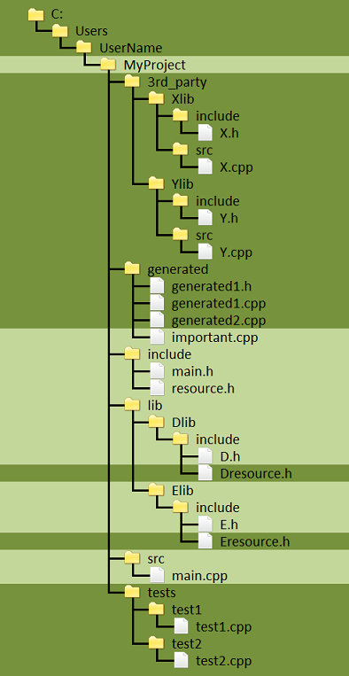

Source code elements in the files marked with darker background will not be considered when creating the results of the analysis.

**-runMetricHunter**

This parameter turns on or off the MetricHunter module. With this feature, SourceMeter lists metric threshold violations. Its value can be “true” (turn this feature on) or “false” (turn this feature off). The default value is “true”.

**-runFaultHunter**

This parameter turns on or off the FaultHunter module. With this feature, SourceMeter identifies common C/C++ coding rule violations (so-called bad practices) in the code. Its value can be “true” (turn this feature on) or “false” (turn this feature off). The default value is “true”.

**-runDCF**

This parameter turns on or off the DuplicatedCodeFinder module. With this feature, SourceMeter identifies copy-pasted code fragments. Its value can be “true” (turn this feature on) or “false” (turn this feature off). The default value is “true”.

**-runMET**

This parameter turns on or off the Metric module. With this feature, SourceMeter computes source code metrics. Its value can be “true” (turn this feature on) or “false” (turn this feature off). The default value is “true”.

**-profileXML**

Global configuration file for SourceMeter. Its *tool-options* tag can be used to override the default metric thresholds for the MetricHunter tool. Furthermore, its *rule-options* tag can enable/disable or modify the priorities of multiple rules. An example profile xml file is shown below:

```xml
      <sourcemeter-profile>
        <tool-options>
          <tool name = "MetricHunter" enabled = "true">
              <metric-thresholds>
                  <threshold metric-id="LOC" relation="gt" value="100" entity="Method" />
                  <threshold metric-id="LLOC" relation="gt" value="none" entity="Method" />
                  <threshold metric-id="NUMPAR" relation="gt" value="43" entity="Method" />
                  <threshold metric-id="TLOC" relation="gt" value="-32" entity="Method" />
              </metric-thresholds>
          </tool>
        </tool-options>

        <rule-options>
          <rule id="IL" name="Member Init Order" priority="Critical" enabled="false"/>
          <rule id="ULTZ" name="Unsigned Compare Less Than Zero" priority="Major" enabled="true"/>
        </rule-options>
      </sourcemeter-profile>
```

**-rulesCSV**

There are certain rule violations that are computed by more than one tool. E.g. OETS (Operator Eq To Self) is checked by both Cppcheck and FaultHunter. In these cases, in order to avoid duplications, there is a priority order among the tools. This parameter can be used to override these default priorizations by specifying a .csv file in the following format:

```
      toolId;CPPCHECK;FHCPP
      ...
      OETS;2;1
      FC;1;-
      FS;1;-
      IL;2;1
      ...
```

**-cloneGenealogy**

This parameter turns on or off the tracking of code clones (copy-pasted source code fragments) through the consecutive revisions of the software system. It is required that during the analysis of the different revisions, the values set to projectName and resultsDir remain the same, so SourceMeter will handle them as different revisions of the same system. Its value can be “true” (turn this feature on) or “false” (turn this feature off). The default value is “false”.

**-cloneMinLines**

This parameter sets the minimum required size of each duplication in lines of code. The default value is 10.

**-csvSeparator**

This parameter sets the separator character in the CSV outputs. The default value is the comma (“,”). The character set here must be placed in quotation marks (e.g. -csvSeparator=“;”). Tabulator character can be set by the special “\t” value.

**-csvDecimalMark**

This parameter sets the decimal mark character in the CSV outputs. The default is value is the dot (“.”). The character set here must be placed in quotation marks (e.g. -csvDecimalMark=“,”).

**-maximumThreads**

This parameter sets the maximum number of parallel tasks the controller can start. The default value is the number of available CPU cores on the current system.

**-currentDate**

The name of the directory with date inside the result directory of the project. If it is not set, then the current date is used.

**-cleanResults**

Cleans all but the last n number of timestamped result directory of the current project.

**-cleanProject**

Removes all files created during the analysis from the given directory recursively.

**-faultTolerant**

This parameter turns on or off the fault tolerant mode. In fault tolerant mode if any non critical error happens, then the analysis will continue and some of the results will be generated. Its value can be “true” (turn this feature on) or “false” (turn this feature off). The default value is “true”.

**-prefix**

We can give a certain prefix for the wrapped program names in Linux to wrapp special versions of these. If it is not set then the following commands are wrapped during the analysis:

Linux: ‘gcc’, ‘g++’, ‘c++’, ‘cc’, ‘ld’, ‘ar’

Windows: ‘cl’, ‘lib’, ‘link’

**-postfix**

We can give a certain postfix for the wrapped program names in Linux to wrapp special versions of these. If it is not set then the following commands are wrapped during the analysis:

Linux: ‘gcc’, ‘g++’, ‘c++’, ‘cc’, ‘ld’, ‘ar’

Windows: ‘cl’, ‘lib’, ‘link’

**-runCppcheck**

This parameter turns on or off the Cppcheck coding rule violation checking. With this feature, SourceMeter lists coding rule violations detected by Cppcheck. Its value can be “true” (turn this feature on) or “false” (turn this feature off). The default value is “true”.

# Usage

The following steps have to be performed to analyze the source code of a software system:

1. The static analysis requires a build script, which contains the commands needed to compile the software system. If this build script is not readily available, it must be prepared as it can be seen in the following example.

   ```
   ---------- build.bat ------------
   msbuild /t:Rebuild /p:Configuration=Release /p:Platform=Win32 Example.sln

   -------- build.sh ------------
   #!/bin/sh
   export SM_DISABLE_ANALYSIS=true
   ./configure
   unset SM_DISABLE_ANALYSIS
   ./make
   ```

2. Create hard and/or soft filter file(s) to filter out unnecessary (e.g. external, generated, or unit tests) source code, if necessary.

   ```
   ---------- SoftFilter.txt ------------
   -C:\\Users\\UserName\\MyProject\\src\\generated
   +C:\\Users\\UserName\\MyProject

   ---------- HardFilter.txt --------
   -conftest
   ```

3. Execute SourceMeter:

   Example (Windows):

   ```
   C:\Users\UserName\SourceMeter\CPP\SourceMeterCPP
    -projectName=MyProject
    -buildScript=MyProject\\build.bat
    -resultsDir=Results
    -externalSoftFilter=SoftFilter.txt
    -externalHardFilter=HardFilter.txt
   ```

   Example (Linux):

   ```
   ~$ SourceMeter/CPP/SourceMeterCPP
    -projectName=MyProject
    -buildScript=MyProject/build.sh
    -resultsDir=Results
    -externalSoftFilter=SoftFilter.txt
    -externalHardFilter=HardFilter.txt
   ```

# Result files

If any critical problems occur in the execution of the tools of the SourceMeter package during the code analysis, SourceMeter returns with non zero exit code. The error code of the given tool appears on the screen (detailed information on the bug can be found in the log directory), and the analysis stops, but the result files created until the failure are not deleted. Unless the fault tolerant mode is disabled the SourceMeter tries to generate as much result as it can with tolerating the not critical errors. If the fault tolerant mode is disabled with the faultTolerant parameter, then the analysis will stop in case of any error.

An error-free execution of SourceMeter produces the following files:

- Files containing the results of the static analysis in the results directory (set by the resultsDir parameter):
  - $(projectName)\cpp\$(DATE)\$(projectName)-*.csv

    CSV (comma separated values) files containing different metrics: Component, File, Namespace, Class, Interface, Enum, Method, Attribute, and Function level source code metrics, rule violation counts, and clone-related metrics at CloneClass and CloneInstance level.
  - $(projectName)\cpp\$(DATE)\$(projectName)-clones.txt

    List of the code clones (copy-pasted source code fragments) in the system.
  - $(projectName)\cpp\$(DATE)\$(projectName)-MetricHunter.txt

    List of the MetricHunter metric value violations in the system.
  - $(projectName)\cpp\$(DATE)\$(projectName)-FaultHunter.txt

    List of the FaultHunter coding rule violations in the system.
  - $(projectName)\cpp\$(DATE)\$(projectName)-Cppcheck.txt

    List of the Cppcheck coding rule violations in the system.
  - $(projectName)\cpp\$(DATE)\$(projectName).graph

    Binary representation of the result graph containing all the metrics, code clones and coding rule violations.
  - $(projectName)\cpp\$(DATE)\$(projectName).xml

    XML representation of the result graph containing all the metrics, code clones and coding rule violations.
  - $(projectName)\cpp\$(projectName).gsi

    Binary data file containing information for tracking the code clones through the consecutive revisions of the analyzed software system.
- Other files and directories created in the results directory:
  - $(projectName)\cpp\$(DATE)\sourcemeter

    Directory, which contains configuration, binary, ASG, log, and temporary files created during the source code analysis.
  - $(projectName)\cpp\$(DATE)\sourcemeter\asg

    Directory, which contains backup copies of the linked ASG and LIM files, the corresponding filter files, and the GSI file.
  - $(projectName)\cpp\$(DATE)\sourcemeter\graph

    Directory, which contains backup copies of the graph files.
  - $(projectName)\cpp\$(DATE)\sourcemeter\log

    Directory, which contains the log files created during the code analysis.
  - $(projectName)\cpp\$(DATE)\sourcemeter\temp

    Directory, which contains the temporary files created during the code analysis.
- Files created outside the results directory:
  - .csi

    C/C++ language dependent ASG file. The .csi files are created in the .columbus_cpp directory located in the directory of the corresponding object files of the compiled C/C++ source files.
  - .lcsi

    Linked C/C++ language dependent ASG file. It is created in the .columbus_cpp sub-directory of the directory containing the corresponding binary file (binary executable, shared object) produced by the linker programs.
  - .acsi

    Archive of C/C++ language dependent ASG files. The .acsi files are created in the .columbus_cpp directory located in the directory of the corresponding static library files produced by the ‘ar’ program.
  - .fcsi

    Filter file belonging to the linked C/C++ language dependent ASG file (.lcsi). It is created in the corresponding directory of the .lcsi file.

# Coding rule violation suppression

The warnings issued by the rule checker modules can be suppressed in case they are found to be invalid or for any other reason. In the case of the integrated 3<sup>rd</sup> party Cppcheck tool the warnings can be suppressed with the inline comment suppression mechanism of the Cppcheck. In case of the SourceMeter coding issue checker module (FaultHunter) this can be done by marking the code line of the warning with a special one-line comment containing the “NOSM” string.

Example:

```cpp
class A {
  bool operator=(const A&) {   // NOSM
    // cppcheck-suppress unusedVariable
    int i;
  }
};
```

In this example, the “Missing check for self assignment in assignment operator” warning of the FaultHunter module and the “Unused variable” warning of Cppcheck will be suppressed.

The warnings of MetricHunter cannot be suppressed at the moment.

# Demo

The Demo directory of the installation package contains the directory structure, the build and analyzer scripts for the analysis of an example project. The log4cplus open source program is included as the example project, which can also be downloaded from the following URL:

http://sourceforge.net/projects/log4cplus/files/log4cplus-stable/1.1.0/log4cplus-1.1.0.tar.gz

To perform the source code analysis of the demo project, the analyze.bat/analyze.sh script has to be executed.

Contents of the Demo directory:

Windows:

| Demo\ |  |  |
| --- | --- | --- |
|  | log4cplus | # log4cplus project |
|  | log4cplus\log4cplus-1.1.0 | # source code of log4cplus |
|  | log4cplus\build.bat | # builds log4cplus |
|  | log4cplus\analyze.bat | # starts the analysis |
|  | log4cplus\softfilter.txt | # softfilter |

Linux:

| Demo/ |  |  |
| --- | --- | --- |
|  | log4cplus | # log4cplus project |
|  | log4cplus/log4cplus-1.1.0 | # source code of log4cplus |
|  | log4cplus/build.sh | # builds log4cplus |
|  | log4cplus/analyze.sh | # starts the analysis |
|  | log4cplus/softfilter.txt | # softfilter |

# Error messages

- Message: There is no valid license!

  Solution: Install a valid license key file (see Installation section).
- Message: Please set the resultsDir parameter. Under this directory a new directory with the name of the analyzed project will be created, if it does not exist yet. All results will be stored there under separate directories with their names containing the date and time.

  Solution: The resultsDir parameter must be set.
- Message: Please set the projectName parameter to the name of the analyzed software system.

  Solution: The projectName parameter must be set.
- Message: Please set the buildScript parameter. This is the script, which will build the project.

  Solution: The buildScript parameter must be set.

# Known bugs and deficiencies

Known bugs and deficiencies of SourceMeter for C/C++.

- SourceMeter places the results into the directory specified by the projectName parameter. If special characters (like ‘<’, ‘>’, etc.) are used in the parameter, the analysis will probably fail.

# FAQ

Frequently Asked Questions regarding SourceMeter.

- Problem: After starting the analysis, neither does the computer show elevated load nor is any of the SourceMeter tools running.

  Solution: SourceMeter creates temporary files during the analysis (e.g. tmp-wrapper.bat) which might be judged as suspicious by certain antivirus programs so they may block them. In these cases, the temporary files must be manually whitelisted.
- Problem: On Windows platforms, in case of deep directory hierarchies, it may happen that the full paths of some files exceed 259 characters. In this case some SourceMeter tools may have problems with opening these files; they will terminate and write appropriate messages in the logs.

  Solution: Move the files to be analyzed to a directory closer to the file system root, or use the ‘subst’ shell command.
- Problem: Analysis of a VS2008 project stops with a critical error of the CAN2Lim task.

  Solution: Use to ‘devenv’ command for building the project instead of the ‘msbuild’ or ‘vcbuild’ commands.

# Appendices

## Reference of source code metrics

Source code metrics are used to quantify different source code characteristics. FrontEndART SourceMeter computes source code metrics for the following source code element kinds: components (e.g. executables), source files, namespaces, class types (including classes, structures, unions, interfaces, and enums), methods, and functions.

The calculated metrics are grouped into 6 categories, which are the following:

- **Cohesion metrics:** measure to what extent the source code elements are coherent in the system.
- **Complexity metrics:** measure the complexity of source code elements (typically algorithms).
- **Coupling metrics:** measure the amount of interdependencies of source code elements.
- **Documentation metrics:** measure the amount of comments and documentation of source code elements in the system.
- **Inheritance metrics:** measure the different aspects of the inheritance hierarchy of the system.
- **Size metrics:** measure the basic properties of the analyzed system in terms of different cardinalities (e.g. number of code lines, number of classes or methods).

In the case of the documentation metrics all the comments found immediately before a source code element are considered as its documentation, while the comments contained inside the source code element are considered as its comments.

The following table summarizes the metrics, their abbreviations and their correspondence to different source code element kinds. Note that in the **free version** only the following 14 metrics are available (all other metrics will get the value 0): CBO, CLOC, LCOM5, LLOC, LOC, McCC, NCL, NOI, RFC, TCLOC, TLLOC, TLOC, TNCL, WMC.

| Category | Metric name | Abbreviation | Class | Component | Enum | File | Function | Interface | Method | Namespace | Structure | Union |
| --- | --- | --- | --- | --- | --- | --- | --- | --- | --- | --- | --- | --- |
| Cohesion metrics | Lack of Cohesion in Methods 5 | LCOM5 | X |  |  |  |  |  |  |  | X | X |
| Complexity metrics | Halstead Calculated Program Length | HCPL |  |  |  |  | X |  | X |  |  |  |
|  | Halstead Difficulty | HDIF |  |  |  |  | X |  | X |  |  |  |
|  | Halstead Effort | HEFF |  |  |  |  | X |  | X |  |  |  |
|  | Halstead Number of Delivered Bugs | HNDB |  |  |  |  | X |  | X |  |  |  |
|  | Halstead Program Length | HPL |  |  |  |  | X |  | X |  |  |  |
|  | Halstead Program Vocabulary | HPV |  |  |  |  | X |  | X |  |  |  |
|  | Halstead Time Required to Program | HTRP |  |  |  |  | X |  | X |  |  |  |
|  | Halstead Volume | HVOL |  |  |  |  | X |  | X |  |  |  |
|  | Maintainability Index (Microsoft version) | MIMS |  |  |  |  | X |  | X |  |  |  |
|  | Maintainability Index (Original version) | MI |  |  |  |  | X |  | X |  |  |  |
|  | Maintainability Index (SEI version) | MISEI |  |  |  |  | X |  | X |  |  |  |
|  | Maintainability Index (SourceMeter version) | MISM |  |  |  |  | X |  | X |  |  |  |
|  | McCabe’s Cyclomatic Complexity | McCC |  |  |  | X | X |  | X |  |  |  |
|  | Nesting Level | NL | X |  |  |  | X |  | X |  | X | X |
|  | Nesting Level Else-If | NLE | X |  |  |  | X |  | X |  | X | X |
|  | Weighted Methods per Class | WMC | X |  |  |  |  | X |  |  | X |  |
| Coupling metrics | Coupling Between Object classes | CBO | X |  |  |  |  | X |  |  | X | X |
|  | Coupling Between Object classes Inverse | CBOI | X |  |  |  |  | X |  |  | X | X |
|  | Number of Incoming Invocations | NII | X |  |  |  | X | X | X |  | X | X |
|  | Number of Outgoing Invocations | NOI | X |  |  |  | X |  | X |  | X | X |
|  | Response set For Class | RFC | X |  |  |  |  |  |  |  | X | X |
| Documentation metrics | API Documentation | AD | X |  | X |  |  | X |  | X | X | X |
|  | Comment Density | CD | X |  |  |  | X |  | X | X | X | X |
|  | Comment Lines of Code | CLOC | X |  |  | X | X | X | X | X | X | X |
|  | Documentation Lines of Code | DLOC | X |  | X |  | X | X | X |  | X | X |
|  | Public Documented API | PDA | X |  |  | X |  | X |  | X | X | X |
|  | Public Undocumented API | PUA | X |  |  | X |  | X |  | X | X | X |
|  | Total API Documentation | TAD |  | X |  |  |  |  |  | X |  |  |
|  | Total Comment Density | TCD | X | X |  |  | X |  | X | X | X | X |

[output cut: 58 more lines]

### Cohesion metrics

#### Lack of Cohesion in Methods 5 (LCOM5)

**Class, Structure, Union:** number of functionalities of the class. One of the basic principles of object-oriented programming is encapsulation, meaning that attributes belonging together and the operations that use them should be organized into one class, and one class shall implement only one functionality, i.e. its attributes and methods should be coherent. This metric measures the lack of cohesion and computes into how many coherent classes the class could be split. It is calculated by taking a non-directed graph, where the nodes are the implemented local methods of the class and there is an edge between the two nodes if and only if a common (local or inherited) attribute or abstract method is used or a method invokes another. The value of the metric is the number of connected components in the graph not counting those, which contain only constructors, destructors, getters, or setters.

### Complexity metrics

#### Halstead Calculated Program Length (HCPL)

**Method, Function:**

- *n1*: number of distinct operators (semantic meanings of the reserved keywords, semicolons, blocks, and identifiers except in their declarations)
- *n2*: number of distinct operands (literals - e.g. character, string, and integer literals, - and the identifiers in their declarations)

The calculated program length is *n1 * log<sub>2</sub>(n1) + n2 * log<sub>2</sub>(n2)*.

#### Halstead Difficulty (HDIF)

**Method, Function:**

- *n1*: number of distinct operators (semantic meanings of the reserved keywords, semicolons, blocks, and identifiers except in their declarations)
- *n2*: number of distinct operands (literals - e.g. character, string, and integer literals, - and the identifiers in their declarations)
- *N2*: total number of operands

The Halstead difficulty is *n1/2 * N2/n2*.

#### Halstead Effort (HEFF)

**Method, Function:**

- *n1*: number of distinct operators (semantic meanings of the reserved keywords, semicolons, blocks, and identifiers except in their declarations)
- *n2*: number of distinct operands (literals - e.g. character, string, and integer literals, - and the identifiers in their declarations)
- *N1*: total number of operators
- *N2*: total number of operands
- *n : n1 + n2* (program vocabulary)
- *N : N1 + N2* (program length)
- *V : N * log<sub>2</sub>(n)* (volume)
- *D : n1/2 * N2/n2* (difficulty)

The Halstead effort is *D * V*.

#### Halstead Number of Delivered Bugs (HNDB)

**Method, Function:**

- *n1*: number of distinct operators (semantic meanings of the reserved keywords, semicolons, blocks, and identifiers except in their declarations)
- *n2*: number of distinct operands (literals - e.g. character, string, and integer literals, - and the identifiers in their declarations)
- *N1*: total number of operators
- *N2*: total number of operands
- *n : n1 + n2* (program vocabulary)
- *N : N1 + N2* (program length)
- *V : N * log<sub>2</sub>(n)* (volume)
- *D : n1/2 * N2/n2* (difficulty)
- *E : D * V* (effort)

Number of delivered bugs is *E<sup>2/3</sup>/3000*.

#### Halstead Program Length (HPL)

**Method, Function:**

- *N1*: total number of operators (semantic meanings of the reserved keywords, semicolons, blocks, and identifiers except in their declarations)
- *N2*: total number of operands (literals - e.g. character, string, and integer literals, - and the identifiers in their declarations)

Halstead program length is *N1 + N2*.

#### Halstead Program Vocabulary (HPV)

**Method, Function:**

- *n1*: number of distinct operators (semantic meanings of the reserved keywords, semicolons, blocks, and identifiers except in their declarations)
- *n2*: number of distinct operands (literals - e.g. character, string, and integer literals, - and the identifiers in their declarations)

Halstead program vocabulary is *n1 + n2*.

#### Halstead Time Required to Program (HTRP)

**Method, Function:**

- *n1*: number of distinct operators (semantic meanings of the reserved keywords, semicolons, blocks, and identifiers except in their declarations)
- *n2*: number of distinct operands (literals - e.g. character, string, and integer literals, - and the identifiers in their declarations)
- *N1*: total number of operators
- *N2*: total number of operands
- *n : n1 + n2* (program vocabulary)
- *N : N1 + N2* (program length)
- *V : N * log<sub>2</sub>(n)* (volume)
- *D : n1/2 * N2/n2* (difficulty)
- *E : D * V* (effort)

Halstead time required to program is *E/18* seconds.

#### Halstead Volume (HVOL)

**Method, Function:**

- *n1*: number of distinct operators (semantic meanings of the reserved keywords, semicolons, blocks, and identifiers except in their declarations)
- *n2*: number of distinct operands (literals - e.g. character, string, and integer literals, - and the identifiers in their declarations)
- *N1*: total number of operators
- *N2*: total number of operands
- *n : n1 + n2* (program vocabulary)
- *N : N1 + N2* (program length)

The Halstead volume is *N * log<sub>2</sub>(n)*.

#### Maintainability Index (Microsoft version) (MIMS)

- *HVOL*: Halstead Volume
- *McCC*: McCabe’s cyclomatic complexity
- *LLOC*: logical lines of code

The Maintainability Index used by Microsoft’s Visual Studio is computed by the following formula:

*MIMS = max(0,(171 - 5.2 * ln(HVOL) - 0.23 * (McCC) - 16.2 * ln(LLOC)) * 100 / 171)*

#### Maintainability Index (Original version) (MI)

- *HVOL*: Halstead Volume
- *McCC*: McCabe’s cyclomatic complexity
- *LLOC*: logical lines of code

The original Maintainability Index is computed by the following formula:

*MI = 171 - 5.2 * ln(HVOL) - 0.23 * (McCC) - 16.2 * ln(LLOC)*

#### Maintainability Index (SEI version) (MISEI)

- *HVOL*: Halstead Volume
- *McCC*: McCabe’s cyclomatic complexity
- *LLOC*: logical lines of code
- *CD*: comment density

The Maintainability Index derived by the Software Engineering Institute (SEI) is computed by the following formula:

*MISEI = 171 - 5.2 * log<sub>2</sub>(HVOL) - 0.23 * McCC - 16.2 * log<sub>2</sub>(LLOC) + 50 * sin(sqrt(2.4 * CD))*

#### Maintainability Index (SourceMeter version) (MISM)

- *HVOL*: Halstead Volume
- *McCC*: McCabe’s cyclomatic complexity
- *LLOC*: logical lines of code
- *CD*: comment density

The Maintainability Index proposed by SourceMeter combines the different scaling approach from Microsoft’s version with the inclusion of comment percentage from the Software Engineering Institute (SEI) version into the following formula:

*MISM = max(0, (171 - 5.2 * log<sub>2</sub>(HVOL) - 0.23 * McCC - 16.2 * log<sub>2</sub>(LLOC) + 50 * sin(sqrt(2.4 * CD))) * 100 / 171)*

#### McCabe’s Cyclomatic Complexity (McCC)

**Method, Function:** complexity of the method expressed as the number of independent control flow paths in it. It represents a lower bound for the number of possible execution paths in the source code and at the same time it is an upper bound for the minimum number of test cases needed for achieving full branch test coverage. The value of the metric is calculated as the number of the following instructions plus 1: if, for, foreach, range-based for, while, do-while, case label (which belongs to a switch instruction), catch, conditional expression (?:). Moreover, logical “and” (&&) and logical “or” (||) expressions also add 1 to the value because their short-circuit evaluation can cause branching depending on the first operand. The following instructions are not included: else, switch, default label (which belongs to a switch instruction), try.

**File:** complexity of the file expressed as the number of independent control flow paths in it. It represents a lower bound for the number of possible execution paths in the source code and at the same time it is an upper bound for the minimum number of test cases needed for achieving full branch test coverage. The value of the metric is calculated as the number of the following instructions plus 1: if, for, foreach, range-based for, while, do-while, case label (which belongs to a switch instruction), catch, conditional expression (?:). Moreover, logical “and” (&&) and logical “or” (||) expressions also add 1 to the value because their short-circuit evaluation can cause branching depending on the first operand. The following instructions are not included: else, switch, default label (which belongs to a switch instruction), try.

#### Nesting Level (NL)

**Method, Function:** complexity of the method expressed as the depth of the maximum embeddedness of its conditional, iteration and exception handling block scopes. The following instructions are taken into account: if, else-if, else, for, while, do-while, switch, try, catch and block statements that are directly inside another block statement. The following instructions do not increase the value by themselves; however, if additional embeddednesses can be found in their blocks, they are considered: case and default label (which belong to a switch instruction).

**Class, Structure, Union:** complexity of the class expressed as the depth of the maximum embeddedness of its conditional, iteration and exception handling block scopes. It is calculated as the maximum nesting level (NL) of its local methods.

#### Nesting Level Else-If (NLE)

**Method, Function:** complexity of the method expressed as the depth of the maximum embeddedness of its conditional, iteration and exception handling block scopes, where in the if-else-if construct only the first if instruction is considered. The following instructions are taken into account: if, else, for, while, do-while, switch, try, catch and block statements that are directly inside another block statement. The following instructions do not increase the value by themselves; however, if additional embeddednesses can be found in their blocks, they are considered: else-if (i.e. in the if-else-if construct the use of else-if does not increase the value of the metric), case and default label (which belong to a switch instruction).

**Class, Structure, Union:** complexity of the class expressed as the depth of the maximum embeddedness of its conditional, iteration and exception handling block scopes, where in the if-else-if construct only the first if instruction is considered. It is calculated as the maximum nesting level (NLE) of its local methods.

#### Weighted Methods per Class (WMC)

**Class, Structure, Interface:** complexity of the class expressed as the number of independent control flow paths in it. It is calculated as the sum of the McCabe’s Cyclomatic Complexity (McCC) values of its local methods.

### Coupling metrics

#### Coupling Between Object classes (CBO)

**Class, Structure, Union, Interface:** number of directly used other classes (e.g. by inheritance, function call, type reference, attribute reference). Classes using many other classes highly depend on their environment, so it is difficult to test or reuse them; furthermore, they are very sensitive to the changes in the system.

#### Coupling Between Object classes Inverse (CBOI)

**Class, Structure, Union, Interface:** number of other classes, which directly use the class. Classes which are used by many other classes have a high impact on the behavior of the system, and should be modified very carefully and tested intensively.

#### Number of Incoming Invocations (NII)

**Method, Function:** number of other methods and attribute initializations which directly call the method. If the method is invoked several times from the same method or attribute initialization, it is counted only once.

**Class, Structure, Union, Interface:** number of other methods and attribute initializations which directly call the local methods of the class. If a method is invoked several times from the same method or attribute initialization, it is counted only once.

#### Number of Outgoing Invocations (NOI)

**Method, Function:** number of directly called methods. If a method is invoked several times, it is counted only once.

**Class, Structure, Union:** number of directly called methods of other classes, including method invocations from attribute initializations. If a method is invoked several times, it is counted only once.

#### Response set For Class (RFC)

**Class, Structure, Union:** number of local (i.e. not inherited) methods in the class (NLM) plus the number of directly invoked other methods by its methods or attribute initializations (NOI).

### Documentation metrics

#### API Documentation (AD)

**Class, Structure, Union, Interface:** ratio of the number of documented public methods in the class +1 if the class itself is documented to the number of all public methods in the class + 1 (the class itself); however, the nested, anonymous, and local classes are not included.

**Enum:** ratio of the number of documented enumerators in the enum +1 if the enum itself is documented to the number of all enumerators in the enum + 1 (the enum itself).

**Namespace:** ratio of the number of documented public classes and methods in the namespace to the number of all of its public classes and methods; however, the classes and methods of its subnamespaces are not included.

#### Comment Density (CD)

**Method, Function:** ratio of the comment lines of the method (CLOC) to the sum of its comment (CLOC) and logical lines of code (LLOC).

**Class, Structure, Union:** ratio of the comment lines of the class (CLOC) to the sum of its comment (CLOC) and logical lines of code (LLOC).

**Namespace:** ratio of the comment lines of the namespace (CLOC) to the sum of its comment (CLOC) and logical lines of code (LLOC).

#### Comment Lines of Code (CLOC)

**Method, Function:** number of comment and documentation code lines of the method; however, its anonymous and local classes are not included.

**Class, Structure, Union, Interface:** number of comment and documentation code lines of the class, including its local methods and attributes; however, its nested, anonymous, and local classes are not included.

**Namespace:** number of comment and documentation code lines of the namespace; however, its subnamespaces are not included.

**File:** number of comment and documentation code lines of the file.

#### Documentation Lines of Code (DLOC)

**Method, Function:** number of documentation code lines of the method.

**Class, Structure, Union, Interface:** number of documentation code lines of the class, including its local methods and attributes; however, its nested, anonymous, and local classes are not included.

**Enum:** number of documentation code lines of the enum, including its enumerators.

#### Public Documented API (PDA)

**Class, Structure, Union, Interface:** number of documented public methods in the class (+1 if the class itself is documented); however, the methods of its nested, anonymous, and local classes are not counted.

**Namespace:** number of documented public classes and methods in the namespace; however, the classes and methods of its subnamespaces are not counted.

**File:** number of documented public classes and methods in the file.

#### Public Undocumented API (PUA)

**Class, Structure, Union, Interface:** number of undocumented public methods in the class (+1 if the class itself is undocumented); however, the methods of its nested, anonymous, and local classes are not counted.

**Namespace:** number of undocumented public classes and methods in the namespace; however, the classes and methods of its subnamespaces are not counted.

**File:** number of undocumented public classes and methods in the file.

#### Total API Documentation (TAD)

**Namespace:** ratio of the number of documented public classes and methods in the namespace to the number of all of its public classes and methods, including its subnamespaces.

**Component:** ratio of the number of documented public classes and methods in the component to the number of all of its public classes and methods, including its subcomponents.

#### Total Comment Density (TCD)

**Method, Function:** ratio of the total comment lines of the method (TCLOC) to the sum of its total comment (TCLOC) and total logical lines of code (TLLOC).

**Class, Structure, Union:** ratio of the total comment lines of the class (TCLOC) to the sum of its total comment (TCLOC) and total logical lines of code (TLLOC).

**Namespace:** ratio of the total comment lines of the namespace (TCLOC) to the sum of its total comment (TCLOC) and total logical lines of code (TLLOC).

**Component:** ratio of the total comment lines of the component (TCLOC) to the sum of its total comment (TCLOC) and total logical lines of code (TLLOC).

#### Total Comment Lines of Code (TCLOC)

**Method, Function:** number of comment and documentation code lines of the method, including its anonymous and local classes.

**Class, Structure, Union, Interface:** number of comment and documentation code lines of the class, including its local methods and attributes, as well as its nested, anonymous, and local classes.

**Namespace:** number of comment and documentation code lines of the namespace, including its subnamespaces.

**Component:** number of comment and documentation code lines of the component, including its subcomponents.

#### Total Public Documented API (TPDA)

**Namespace:** number of documented public classes and methods in the namespace, including the documented public classes and methods of its subnamespaces.

**Component:** number of documented public classes and methods in the component, including the documented public classes and methods of its subcomponents.

#### Total Public Undocumented API (TPUA)

**Namespace:** number of undocumented public classes and methods in the namespace, including the undocumented public classes and methods of its subnamespaces.

**Component:** number of undocumented public classes and methods in the component, including the undocumented public classes and methods of its subcomponents.

### Inheritance metrics

#### Depth of Inheritance Tree (DIT)

**Class, Structure, Interface:** length of the path that leads from the class to its farthest ancestor in the inheritance tree.

#### Number of Ancestors (NOA)

**Class, Structure, Interface:** number of classes, interfaces, enums and annotations from which the class is directly or indirectly inherited.

#### Number of Children (NOC)

**Class, Structure, Interface:** number of classes, interfaces, enums and annotations which are directly derived from the class.

#### Number of Descendants (NOD)

**Class, Structure, Interface:** number of classes, interfaces, enums, annotations, which are directly or indirectly derived from the class.

#### Number of Parents (NOP)

**Class, Structure, Interface:** number of classes, interfaces, enums and annotations from which the class is directly inherited.

### Size metrics

#### Lines of Code (LOC)

**Method, Function:** number of code lines of the method, including empty and comment lines; however, its anonymous and local classes are not included.

**Class, Structure, Union, Interface:** number of code lines of the class, including empty and comment lines, as well as its local methods; however, its nested, anonymous, and local classes are not included.

**Enum:** number of code lines of the enum, including empty and comment lines.

**Namespace:** number of code lines of the namespace, including empty and comment lines; however, its subnamespaces are not included.

**File:** number of code lines of the file, including empty and comment lines.

#### Logical Lines of Code (LLOC)

**Method, Function:** number of non-empty and non-comment code lines of the method; however, its anonymous and local classes are not included.

**Class, Structure, Union, Interface:** number of non-empty and non-comment code lines of the class, including the non-empty and non-comment lines of its local methods; however, its nested, anonymous, and local classes are not included.

**Enum:** number of non-empty and non-comment code lines of the enum.

**Namespace:** number of non-empty and non-comment code lines of the namespace; however, its subnamespaces are not included.

**File:** number of non-empty and non-comment code lines of the file.

#### Number of Attributes (NA)

**Class, Structure, Union, Interface:** number of attributes in the class, including the inherited ones; however, the attributes of its nested, anonymous, and local classes are not included.

**Enum:** number of enumerators in the enum.

**Namespace:** number of attributes in the namespace; however, attributes of its subnamespaces are not included.

#### Number of Classes (NCL)

**Namespace:** number of classes in the namespace; however, the classes of its subnamespaces are not included.

#### Number of Enums (NEN)

**Namespace:** number of enums in the namespace; however, the enums of its subnamespaces are not included.

#### Number of Getters (NG)

**Class, Structure, Union, Interface:** number of getter methods in the class, including the inherited ones; however, the getter methods of its nested, anonymous, and local classes are not included. Methods that override abstract methods are not counted.

**Namespace:** number of getter methods in the namespace; however, getter methods of its subnamespaces are not included.

#### Number of Interfaces (NIN)

**Namespace:** number of interfaces in the namespace; however, the interfaces of its subnamespaces are not included.

#### Number of Local Attributes (NLA)

**Class, Structure, Interface:** number of local (i.e. not inherited) attributes in the class; however, the attributes of nested, anonymous, and local classes are not included.

#### Number of Local Getters (NLG)

**Class, Structure, Interface:** number of local (i.e. not inherited) getter methods in the class; however, the getter methods of its nested, anonymous, and local classes are not included. Methods that override abstract methods are not counted.

#### Number of Local Methods (NLM)

**Class, Structure, Interface:** number of local (i.e. not inherited) methods in the class; however, the methods of nested, anonymous, and local classes are not included.

#### Number of Local Public Attributes (NLPA)

**Class, Structure, Interface:** number of local (i.e. not inherited) public attributes in the class; however, the attributes of nested, anonymous, and local classes are not included.

#### Number of Local Public Methods (NLPM)

**Class, Structure, Interface:** number of local (i.e. not inherited) public methods in the class; however, the methods of nested, anonymous, and local classes are not included.

#### Number of Local Setters (NLS)

**Class, Structure, Interface:** number of local (i.e. not inherited) setter methods in the class; however, the setter methods of its nested, anonymous, and local classes are not included. Methods that override abstract methods are not counted.

#### Number of Methods (NM)

**Class, Structure, Union, Interface:** number of methods in the class, including the inherited ones; however, the methods of its nested, anonymous and local classes are not included. Methods that override abstract methods are not counted.

**Namespace:** number of methods in the namespace; however, methods of its subnamespaces are not included.

#### Number of Packages (NPKG)

**Namespace:** number of directly contained subnamespaces of the namespace.

#### Number of Parameters (NUMPAR)

**Method, Function:** number of the parameters of the method. The varargs parameter counts as one.

#### Number of Public Attributes (NPA)

**Class, Structure, Union, Interface:** number of public attributes in the class, including the inherited ones; however, the public attributes of its nested, anonymous, and local classes are not included.

**Namespace:** number of public attributes in the namespace; however, the public attributes of its subnamespaces are not included.

#### Number of Public Methods (NPM)

**Class, Structure, Union, Interface:** number of public methods in the class, including the inherited ones; however, the public methods of nested, anonymous, and local classes are not included. Methods that override abstract methods are not counted.

**Namespace:** number of public methods in the namespace; however, the public methods of its subnamespaces are not included.

#### Number of Setters (NS)

**Class, Structure, Union, Interface:** number of setter methods in the class, including the inherited ones; however, the setter methods of its nested, anonymous, and local classes are not included. Methods that override abstract methods are not counted.

**Namespace:** number of setter methods in the namespace; however, setter methods of its subnamespaces are not included.

#### Number of Statements (NOS)

**Method, Function:** number of statements in the method; however, the statements of its anonymous and local classes are not included.

**Class, Structure, Union:** number of statements in the class; however, the statements of its nested, anonymous, and local classes are not included.

**File:** number of statements in the file.

#### Number of Structures (NST)

**Namespace:** number of structures in the namespace; however, the structures of its subnamespaces are not included.

#### Number of Unions (NUN)

**Namespace:** number of unions in the namespace; however, the unions of its subnamespaces are not included.

#### Total Lines of Code (TLOC)

**Method, Function:** number of code lines of the method, including empty and comment lines, as well as its anonymous and local classes.

**Class, Structure, Union, Interface:** number of code lines of the class, including empty and comment lines, as well as its local methods, anonymous, local, and nested classes.

**Namespace:** number of code lines of the namespace, including empty and comment lines, as well as its subnamespaces.

**Component:** number of code lines of the component, including empty and comment lines, as well as its subcomponents.

#### Total Logical Lines of Code (TLLOC)

**Method, Function:** number of non-empty and non-comment code lines of the method, including the non-empty and non-comment lines of its anonymous and local classes.

**Class, Structure, Union, Interface:** number of non-empty and non-comment code lines of the class, including the non-empty and non-comment code lines of its local methods, anonymous, local, and nested classes.

**Namespace:** number of non-empty and non-comment code lines of the namespace, including its subnamespaces.

**Component:** number of non-empty and non-comment code lines of the component, including its subcomponents.

#### Total Number of Attributes (TNA)

**Class, Structure, Union, Interface:** number of attributes in the class, including the inherited ones, as well as the inherited and local attributes of its nested, anonymous and local classes.

**Namespace:** number of attributes in the namespace, including the attributes of its subnamespaces.

**Component:** number of attributes in the component, including the attributes of its subcomponents.

#### Total Number of Classes (TNCL)

**Namespace:** number of classes in the namespace, including the classes of its subnamespaces.

**Component:** number of classes in the component, including the classes of its subcomponents.

#### Total Number of Directories (TNDI)

**Namespace:** number of directories that belong to the namespace, including the directories of its subnamespaces.

**Component:** number of directories that belong to the component, including its subcomponents.

#### Total Number of Enums (TNEN)

**Namespace:** number of enums in the namespace, including the enums of its subnamespaces.

**Component:** number of enums in the component, including the enums of its subcomponents.

#### Total Number of Files (TNFI)

**Namespace:** number of files that belong to the namespace, including the files of its subnamespaces.

**Component:** number of files that belong to the component, including its subcomponents.

#### Total Number of Getters (TNG)

**Class, Structure, Union, Interface:** number of getter methods in the class, including the inherited ones, as well as the inherited and local getter methods of its nested, anonymous and local classes.

**Namespace:** number of getter methods in the namespace, including the getter methods of its subnamespaces.

**Component:** number of getter methods in the component, including the getter methods of its subcomponents.

#### Total Number of Interfaces (TNIN)

**Namespace:** number of interfaces in the namespace, including the interfaces of its subnamespaces.

**Component:** number of interfaces in the component, including the interfaces of its subcomponents.

#### Total Number of Local Attributes (TNLA)

**Class, Structure, Interface:** number of local (i.e. not inherited) attributes in the class, including the attributes of its nested, anonymous, and local classes.

#### Total Number of Local Getters (TNLG)

**Class, Structure, Interface:** number of local (i.e. not inherited) getter methods in the class, including the local getter methods of its nested, anonymous, and local classes.

#### Total Number of Local Methods (TNLM)

**Class, Structure, Interface:** number of local (i.e. not inherited) methods in the class, including the local methods of its nested, anonymous, and local classes.

#### Total Number of Local Public Attributes (TNLPA)

**Class, Structure, Interface:** number of local (i.e. not inherited) public attributes in the class, including the local public attributes of its nested, anonymous, and local classes.

#### Total Number of Local Public Methods (TNLPM)

**Class, Structure, Interface:** number of local (i.e. not inherited) public methods in the class, including the local methods of its nested, anonymous, and local classes.

#### Total Number of Local Setters (TNLS)

**Class, Structure, Interface:** number of local (i.e. not inherited) setter methods in the class, including the local setter methods of its nested, anonymous, and local classes.

#### Total Number of Methods (TNM)

**Class, Structure, Union, Interface:** number of methods in the class, including the inherited ones, as well as the inherited and local methods of its nested, anonymous, and local classes. Methods that override abstract methods are not counted.

**Namespace:** number of methods in the namespace, including the methods of its subnamespaces.

**Component:** number of methods in the component, including the methods of its subcomponents.

#### Total Number of Packages (TNPKG)

**Namespace:** number of subnamespaces in the namespace, including all directly or indirectly contained subnamespaces.

**Component:** number of namespaces and subnamespaces that belong to the component, including its subcomponents.

#### Total Number of Public Attributes (TNPA)

**Class, Structure, Union, Interface:** number of public attributes in the class, including the inherited ones, as well as the inherited and local public attributes of its nested, anonymous, and local classes.

**Namespace:** number of public attributes in the namespace, including the public attributes of its subnamespaces.

**Component:** number of public attributes in the component, including the public attributes of its subcomponents.

#### Total Number of Public Classes (TNPCL)

**Namespace:** number of public classes in the namespace, including the public classes of its subnamespaces.

**Component:** number of public classes in the component, including the public classes of its subcomponents.

#### Total Number of Public Enums (TNPEN)

**Namespace:** number of public enums in the namespace, including the public enums of its subnamespaces.

**Component:** number of public enums in the component, including the public enums of its subcomponents.

#### Total Number of Public Interfaces (TNPIN)

**Namespace:** number of public interfaces in the namespace, including the public interfaces of its subnamespaces.

**Component:** number of public interfaces in the component, including the public interfaces of its subcomponents.

#### Total Number of Public Methods (TNPM)

**Class, Structure, Union, Interface:** number of public methods in the class, including the inherited ones, as well as the inherited and local public methods of its nested, anonymous, and local classes.

**Namespace:** number of public methods in the namespace, including the public methods of its subnamespaces.

**Component:** number of public methods in the component, including the public methods of its subcomponents.

#### Total Number of Public Structures (TNPST)

**Namespace:** number of public structures in the namespace, including the public structures of its subnamespaces.

**Component:** number of public structures in the component, including the public structures of its subcomponents.

#### Total Number of Public Unions (TNPUN)

**Namespace:** number of public unions in the namespace, including the public unions of its subnamespaces.

**Component:** number of public unions in the component, including the public unions of its subcomponents.

#### Total Number of Setters (TNS)

**Class, Structure, Union, Interface:** number of setter methods in the class, including the inherited ones, as well as the inherited and local setter methods of its nested, anonymous and local classes.

**Namespace:** number of setter methods in the namespace, including the setter methods of its subnamespaces.

**Component:** number of setter methods in the component, including the setter methods of its subcomponents.

#### Total Number of Statements (TNOS)

**Method, Function:** number of statements in the method, including the statements of its anonymous and local classes.

**Class, Structure, Union:** number of statements in the class, including the statements of its nested, anonymous, and local classes.

**Namespace:** number of statements in the namespace, including the statements of its subnamespaces.

**Component:** number of statements in the component, including the statements of its subcomponents.

#### Total Number of Structures (TNST)

**Namespace:** number of structures in the namespace, including the structures of its subnamespaces.

**Component:** number of structures in the component, including the structures of its subcomponents.

#### Total Number of Unions (TNUN)

**Namespace:** number of unions in the namespace, including the unions of its subnamespaces.

**Component:** number of unions in the component, including the unions of its subcomponents.

## Reference of code duplication metrics

Code cloning (or copy-paste programming) means the copying of an existing piece of source code, pasting it somewhere else, and typically performing smaller modifications on it. Based on the level of similarity between the copied code fragments we can define the following duplication types:

- **Type-1**: the copied code parts are identical code fragments except for variations in whitespace, layout and comments.
- **Type-2**: syntactically identical fragments except for variations in identifier names, literals, type references, whitespace, layout and comments.
- **Type-3**: copied fragments with further modifications such as altered, added, or removed statements, in addition to variations in identifier names, literals, type references, whitespace, layout and comments.
- **Type-4**: the copied code fragments are syntactically different, but they perform the same functionality, i.e. they are semantically the same.

FrontEndART SourceMeter is capable of identifying Type-2 clones, i.e. code fragments that are structurally identical, but may differ in variable names, literals, identifiers, etc.

Two code segments correspond to each other if they are copies of each other. This relation is an equivalence relation and we use the notion of clone classes to the classes of the relation, and the members of the classes will be referred to as clone instances. Owing to the nature of the relation, each clone class must contain at least two clone instances.

Clones are tracked during the source code analysis of consecutive revisions of the analyzed software system. FrontEndART SourceMeter detects suspicious, inconsistently changing code copies, which are called “clone smells”. The smells concerning clone classes are the following:

- **Disappearing Clone Class (DCC):** The clone class existed in the previously analyzed revision but it does not exist anymore.
- **Appearing Clone Class (ACC):** The clone class did not exist in the previously analyzed revision.

The smells concerning clone instances are issued only if the containing clone class does not contain any smell. These are the following:

- **Disappearing Clone Instance (DCI):** The clone instance existed in the previously analyzed revision but it does not exist anymore.
- **Appearing Clone Instance (ACI):** The clone instance did not exist in the previously analyzed revision.
- **Moving Clone Instance (MCI):** The clone instance belonged to a different clone class in the previously analyzed revision than its current class.

The following table summarizes the code duplication metrics, their abbreviations, and their correspondence to different source code element types.

| Metric name | Abbrev. | Clone Instance | Clone Class | Method, Function | Class, Struct, Union, Interface, Enum | Namespace | Comp. |
| --- | --- | --- | --- | --- | --- | --- | --- |
| Clone Age | CA | X | X |  |  |  |  |
| Clone Classes | CCL |  |  | X | X | X | X |
| Clone Complexity | CCO | X | X | X | X | X | X |
| Clone Coverage | CC |  |  | X | X | X | X |
| Clone Elimination Effort | CEE |  | X |  |  |  | X |
| Clone Elimination Gain | CEG |  | X |  |  |  | X |
| Clone Embeddedness | CE | X | X |  |  |  |  |
| Clone Instances | CI |  | X | X | X | X | X |
| Clone Line Coverage | CLC |  |  | X | X | X | X |
| Clone Lines of Code | CLLOC | X | X |  |  |  |  |
| Clone Logical Line Coverage | CLLC |  |  | X | X | X | X |
| Clone Risk | CR |  | X |  |  |  | X |
| Clone Variability | CV | X | X |  |  |  |  |
| Lines of Duplicated Code | LDC |  |  | X | X | X | X |
| Logical Lines of Duplicated Code | LLDC |  |  | X | X | X | X |
| Normalized Clone Radius | NCR |  | X |  |  |  | X |

### Clone metrics

#### Clone Age (CA)

**Clone class/clone instance:** number of previously analyzed revisions in which the clone class/clone instance was present + 1.

#### Clone Classes (CCL)

**Method/class/package:** number of clone classes having at least one clone instance in the source code element.

**Component:** number of clone classes having at least one clone instance in the component.

#### Clone Complexity (CCO)

**Clone instance:** the McCabe complexity of the code fragment corresponding to the clone instance.

**Clone class:** sum of CCO of clone instances in the clone class.

**Function/method/class/module/package:** sum of CCO of clone instances in the source code element.

**Component:** sum of CCO of clone instances in the component.

#### Clone Coverage (CC)

**Method/Function/Union/Enum/class/Structure/Namespace:** ratio of code covered by code duplications in the source code element to the size of the source code element, expressed in terms of the number of syntactic entities (statements, expressions, etc.).

**Component:** ratio of code covered by code duplications in the component to the size of the component, expressed in terms of the number of syntactic entities (statements, expressions, etc.).

#### Clone Elimination Effort (CEE)[^2]

**Clone class:** index of the effort required to eliminate the clone class. It is computed as the product of CI, CE, and NCR.

**Component:** index of the effort required to eliminate all clones from the component. It is computed as the sum of CEE of the clone classes in the component.

#### Clone Elimination Gain (CEG)[^3]

**Clone class:** index of the gain resulting from eliminating the clone class. It is computed as the ratio of CR to CEE.

**Component:** index of the gain resulting from eliminating all clones from the component. It is computed as the logistic function of the ratio of CR to CEE.

#### Clone Embeddedness (CE)

**Clone instance:** sum of incoming and outgoing references (function calls, variable references, type references; different references to the same entity are counted only once) in the code fragment corresponding to the clone instance, weighted with the number of directory changes between the referenced code fragments.

**Clone class:** sum of CE of the clone instances of the clone class + 1.

#### Clone Instances (CI)

**Method/class/package:** number of clone instances in the source code element.

**Component:** number of clone instances in the component.

**Clone class:** number of clone instances in the clone class.

#### Clone Line Coverage (CLC)

**Function/method/class/module/package:** ratio of code covered by code duplications in the source code element to the size of the source code element, expressed in terms of lines of code.

**Component:** ratio of code covered by code duplications in the component to the size of the component, expressed in terms of lines of code.

#### Clone Lines of Code (CLLOC)

**Clone instance:** length of the clone instance expressed in terms of lines of code.

**Clone class:** average of CLLOC of clone instances belonging to the clone class.

#### Clone Logical Line Coverage (CLLC)

**Function/method/class/module/package:** ratio of code covered by code duplications in the source code element to the size of source code element, expressed in terms of logical lines of code (non-empty, non-comment lines).

**Component:** ratio of code covered by code duplications in the component to the size of the component, expressed in terms of logical lines of code (non-empty, non-comment lines).

#### Clone Risk (CR)[^4]

**Clone class:** risk index of the existence of the clone class. It is computed as the product of CLLOC, CI, CCO, NCR, and CV.

**Component:** relative risk index of the existence of code duplications in the component. It is computed as the sum of CR of the clone classes in the component, divided by the total logical lines of code (non-empty, non-comment lines) of the component. It expresses the risk index projected to a non-empty, non-comment line of code in the component.

#### Clone Variability (CV)

**Clone instance:** instability of the clone instance since it appeared. It is computed as the ratio of the number of previously analyzed revisions when the instance had been changed to its age (CA).

**Clone class:** instability of the clone class since it appeared. It is computed as the ratio of the number of previously analyzed revisions when its contained instances were moved, deleted, or added, to its age (CA), plus the average CV of its clone instances.

#### Lines of Duplicated Code (LDC)

**Function/method/class/module/package:** number of code lines covered by code duplications in the source code element.

**Component:** number of code lines covered by code duplications in the component.

#### Logical Lines of Duplicated Code (LLDC)

**Function/method/class/module/package:** number of logical code lines (non-empty, non-comment lines) covered by code duplications in the source code element.

**Component:** The number of logical code lines (non-empty, non-comment lines) covered by code duplications in the component.

#### Normalized Clone Radius (NCR)

**Clone class:** normalized average distance among clone instances belonging to the clone class, expressed in terms of number of directory changes.

**Component:** average of NCR of the clone classes in the component.

## Reference of FaultHunter coding rule violations

The list of rulesets and rules contained in each ruleset are the following:

- **Exception Rules:** The Exception Ruleset contains rules about throwing and catching exceptions.
- **Object Orientedness Rules:** The Object Orientedness Ruleset contains rules that find various mistakes about classes and other object orientedness related constructs.
- **Performance Rules:** The Performance Ruleset contains rules that find various performance issues.
- **Readability and Consistency Rules:** The Readability and Consistency Ruleset contains rules about constructs that reduce the code readability.
- **Simple Type Rules:** The Simple Type Ruleset contains rules that find simple type related issues.
- **Suspicious Construct Rules:** The Suspicious Construct Ruleset contains rules about constructs that are redundant or could lead to unexpected results.

The following table contains the enabled rules and their priorities:

| Category | Name | Abbreviation | Prio. |
| --- | --- | --- | --- |
| Exception Rules | Catching Non Primitive Type Exceptions By Value | FHCPP_CEBV | Critical |
|  | Not Public Inheritance From Catch Type | FHCPP_NPIFCT | Critical |
|  | Std::exception Not Inherited Publicly | FHCPP_SENIP | Critical |
| Object Orientedness Rules | Member Init Order | FHCPP_IL | Critical |
|  | Missing Virtual Destructor Using Delete | FHCPP_MVDUD | Critical |
|  | Missing Virtual Destructor Using New | FHCPP_MVDUN | Critical |
| Performance Rules | Static Data At Namespace Scope In Header | FHCPP_SDANSIH | Critical |
| Readability and Consistency Rules | Hidden Parameter | FHCPP_HP | Critical |
|  | Not Defined Evaluation Order | FHCPP_NDEO | Critical |
|  | Using Directive In Namespace In Header | FHCPP_UDINIH | Critical |
| Simple Type Rules | Unsigned Compare Less Than Zero | FHCPP_ULTZ | Critical |
| Suspicious Construct Rules | Check For Self Assignment In Assignment Operator | FHCPP_OETS | Critical |
|  | Self Assignment | FHCPP_SA | Critical |

### Exception Rules

#### Catching Non Primitive Type Exceptions By Value

Reference should be used for catching a non primitive type exception.

#### Not Public Inheritance From Catch Type

Not publicly derived class from a type that appears in a catch clause. This class cannot be caught in the catch clause as that base class, because no public conversion exists.

#### Std::exception Not Inherited Publicly

Not publicly derived class from std::exception cannot be caught in the catch clause as std::exception, because no public conversion exists.

### Object Orientedness Rules

#### Member Init Order

The evaluation order in the constructor initialization list does not match the order they listed. It may cause unexpected effects like use of uninitialized class members.

For example the member ‘a’ will be uninitialized when passed to the ‘Bar’ constructor, because the initialization order is the following: ‘Bar’ constructor call, ‘a’, ‘b’.

```cpp
class Foo : public Bar {
  int a;
  int b;
public:
  Foo (int param) : b(param), a(b), Bar(a) {
    ...
  }
}
```

#### Missing Virtual Destructor Using Delete

When using pointers, make sure that the class of the pointer type has virtual destructor if any of its accessible descendant has destructor.

#### Missing Virtual Destructor Using New

When using pointers, make sure that the class of the pointer type has virtual destructor if any of its descendant has destructor.

### Performance Rules

#### Static Data At Namespace Scope In Header

Static data at namespace scope in header files generates one instance inside each compilation unit. It cause bigger executables.

### Readability and Consistency Rules

#### Hidden Parameter

Local variables can hide the parameters of the function, because the local variables are defined in the closest scope. It causes those parameters unreachable.

#### Not Defined Evaluation Order

The order that operands and function parameters are evaluated is unspecified behavior.

For example in the following function call, the value of the first and second arguments could be (4, 5) or (5, 4).

```cpp
int i = 3;
foo(++i, ++i);
```

#### Using Directive In Namespace In Header

“using namespace” should not occour at namespace level in a header.

### Simple Type Rules

#### Unsigned Compare Less Than Zero

Pointless comparison of unsigned integer against zero.

### Suspicious Construct Rules

#### Check For Self Assignment In Assignment Operator

Missing check for self assignment in assignment operator

For example in the following operator the ‘rhs._data’ will be no longer a valid object if it is a self assignment.

```cpp
Foo& operator= (const Foo& rhs) {
  delete this->_data;
  this->_data = new Bar(*rhs._data);
  return *this;
}
```

A simple solution to this problem:

```cpp
Foo& operator= (const Foo& rhs) {
  if (this == &rhs) return *this;
  delete this->_data;
  this->_data = new Bar(*rhs._data);
  return *this;
}
```

#### Self Assignment

Avoid assign an object to itself.

## Reference of Cppcheck coding rule violations

Cppcheck is a static analysis tool for C/C++ code. Unlike C/C++ compilers and many other analysis tools it does not detect syntax errors in the code. Cppcheck primarily detects the types of bugs that the compilers normally do not detect. The goal is to detect only real errors in the code (i.e. have zero false positives).

SourceMeter uses Cppcheck “as is”, without any guaranties that the results of Cppcheck are correct. All statements of the Cppcheck license apply here as well. All texts describing the rulesets and the individual rules are copied from the cppcheck with some minor grammatical fixes.

The list of rulesets and rules contained in each ruleset are the following:

- **API Rules:** The API Ruleset contains rules that find built in function usages that are wrong.
- **Boost Library Rules:** The Boost Library Ruleset contains rules for boost usage.
- **Buffer Overrun Rules:** The Buffer Overrun Ruleset contains rules that find mistakes about buffers usage and array indices.
- **Conditional Rules:** The Conditional Ruleset contains rules that find condition mistakes.
- **Division Rules:** The Division Ruleset contains rules about the division operator.
- **Exception Rules:** The Exception Ruleset contains rules about throwing and catching exceptions.
- **Initialization Rules:** The Initialization Ruleset contains rules about the initialization of allocated memory, variables and members.
- **Input Output Rules:** The Input Output Ruleset contains rules for input output operations.
- **Memory Handling Rules:** The Memory Handling Ruleset contains rules about memory leaks and common memory management problems.
- **Object Orientedness Rules:** The Object Orientedness Ruleset contains rules that find various mistakes about classes and other object orientedness related constructs.
- **Performance Rules:** The Performance Ruleset contains rules that find various performance issues.
- **Portability Rules:** The Portability Ruleset contains rules that find portability issues.
- **Readability and Consistency Rules:** The Readability and Consistency Ruleset contains rules about constructs that reduce the code readability.
- **Reentrancy Rules:** The Reentrancy Ruleset contains rules for non-reentrant functions.
- **STL Rules:** The STL Ruleset contains rules that find mistakes of STL usage (invalidation of iterators, mismatching containers, etc).
- **Side Effect Rules:** The Side Effect Ruleset contains rules that find suspicious constructs that can have side effects.
- **Simple Type Rules:** The Simple Type Ruleset contains rules that find simple type related issues.
- **Sizeof Operator Rules:** The Sizeof Operator Ruleset contains rules that check usage of sizeof operator.
- **Suspicious Construct Rules:** The Suspicious Construct Ruleset contains rules about constructs that are redundant or could lead to unexpected results.
- **Unnecessary and Unused Code Rules:** The Unnecessary and Unused Code Ruleset contains a collection of rules for unnecessary,unused or ineffective code.
- **Unreachable Code Rules:** The Unreachable Code Ruleset contains rules about code sections that can never be executed.
- **Variable Argument Related Rules:** The Variable Argument Related Ruleset contains rules about the usage of va_start and va_end functions.

The following table contains the enabled rules and their priorities:

| Category | Name | Abbreviation | Prio. |
| --- | --- | --- | --- |
| API Rules | Invalid Function Arg | CPPCHECK_IFA | Blocker |
|  | Invalid Function Arg Bool | CPPCHECK_IFAB | Blocker |
|  | Memset Value Out Of Range | CPPCHECK_MVOOR | Critical |
|  | Memset Zero Bytes | CPPCHECK_MZB | Critical |
|  | Obsolete Functions alloca | CPPCHECK_OFAA | Minor |
|  | Obsolete Functions asctime | CPPCHECK_OFAT | Minor |
|  | Obsolete Functions asctime_r | CPPCHECK_OFA | Minor |
|  | Obsolete Functions bcmp | CPPCHECK_OFBCMP | Minor |
|  | Obsolete Functions bcopy | CPPCHECK_OFBCPY | Minor |
|  | Obsolete Functions bsd_signal | CPPCHECK_OFBSS | Minor |
|  | Obsolete Functions bzero | CPPCHECK_OFBZ | Minor |
|  | Obsolete Functions ctime_r | CPPCHECK_OFCT | Minor |
|  | Obsolete Functions ecvt | CPPCHECK_OFECVT | Minor |
|  | Obsolete Functions fcvt | CPPCHECK_OFFCVT | Minor |
|  | Obsolete Functions ftime | CPPCHECK_OFFT | Minor |
|  | Obsolete Functions gcvt | CPPCHECK_OFGCVT | Minor |
|  | Obsolete Functions getcontext | CPPCHECK_OFGC | Minor |
|  | Obsolete Functions gethostbyaddr | CPPCHECK_OFGHBA | Minor |
|  | Obsolete Functions gethostbyname | CPPCHECK_OFGHBN | Minor |
|  | Obsolete Functions gets | CPPCHECK_OFGS | Minor |
|  | Obsolete Functions getwd | CPPCHECK_OFGWD | Minor |
|  | Obsolete Functions index | CPPCHECK_OFI | Minor |
|  | Obsolete Functions makecontext | CPPCHECK_OFMC | Minor |
|  | Obsolete Functions pthread_attr_getstackaddr | CPPCHECK_OFPAGSA | Minor |
|  | Obsolete Functions pthread_attr_setstackaddr | CPPCHECK_OFPASSA | Minor |
|  | Obsolete Functions rand_r | CPPCHECK_OFR | Minor |
|  | Obsolete Functions rindex | CPPCHECK_OFRI | Minor |
|  | Obsolete Functions scalbln | CPPCHECK_OFSB | Minor |
|  | Obsolete Functions swapcontext | CPPCHECK_OFSC | Minor |
|  | Obsolete Functions tmpnam | CPPCHECK_OFTN | Minor |

[output cut: 278 more lines]

### API Rules

#### Invalid Function Arg

Invalid func_name() argument nr 1

#### Invalid Function Arg Bool

Invalid func_name() argument nr 1. A non-boolean value is required.

#### Memset Value Out Of Range

The 2nd memset() argument ‘varname’ doesn’t fit into an ‘unsigned char’. The 2nd parameter is passed as an ‘int’, but the function fills the block of memory using the ‘unsigned char’ conversion of this value.

#### Memset Zero Bytes

memset() called to fill 0 bytes of ‘varname’. The second and third arguments might be inverted. The function memset ( void * ptr, int value, size_t num ) sets the first num bytes of the block of memory pointed by ptr to the specified value.

#### Obsolete Functions alloca

The obsolete function ‘alloca’ is called. In C99 and later it is recommended to use a variable length array or a dynamically allocated array instead. The function ‘alloca’ is dangerous for many reasons (http://stackoverflow.com/questions/1018853/why-is-alloca-not-considered-good-practice and http://linux.die.net/man/3/alloca).

#### Obsolete Functions asctime

Obsolete function ‘asctime’ called. It is recommended to use the function ‘strftime’ instead.

#### Obsolete Functions asctime_r

Obsolete function ‘asctime_r’ called. It is recommended to use the function ‘strftime’ instead.

#### Obsolete Functions bcmp

Obsolete function ‘bcmp’ called. It is recommended to use the function ‘memcmp’ instead.

#### Obsolete Functions bcopy

Obsolete function ‘bcopy’ called. It is recommended to use the ‘memmove’ or ‘memcpy’ function instead.

#### Obsolete Functions bsd_signal

Obsolete function ‘bsd_signal’ called. It is recommended to use the function ‘sigaction’ instead.

#### Obsolete Functions bzero

Obsolete function ‘bzero’ called. It is recommended to use the function ‘memset’ instead.

#### Obsolete Functions ctime_r

Obsolete function ‘ctime_r’ called. It is recommended to use the function ‘strftime’ instead.

#### Obsolete Functions ecvt

Obsolete function ‘ecvt’ called. It is recommended to use the function ‘sprintf’ instead.

#### Obsolete Functions fcvt

Obsolete function ‘fcvt’ called. It is recommended to use the function ‘sprintf’ instead.

#### Obsolete Functions ftime

Obsolete function ‘ftime’ called. It is recommended to use time(), gettimeofday() or clock_gettime() instead.

#### Obsolete Functions gcvt

Obsolete function ‘gcvt’ called. It is recommended to use the function ‘sprintf’ instead.

#### Obsolete Functions getcontext

Obsolete function ‘getcontext’ called. Due to portability issues, applications are recommended to be rewritten to use POSIX threads.

#### Obsolete Functions gethostbyaddr

Obsolete function ‘gethostbyaddr’ called. It is recommended to use the function ‘getnameinfo’ instead.

#### Obsolete Functions gethostbyname

Obsolete function ‘gethostbyname’ called. It is recommended to use the function ‘getaddrinfo’ instead.

#### Obsolete Functions gets

The obsolete function ‘gets’ is called. With ‘gets’ you’ll get a buffer overrun if the input data exceeds the size of the buffer. It is recommended to use the function ‘fgets’ instead.

#### Obsolete Functions getwd

Obsolete function ‘getwd’ called. It is recommended to use the function ‘getcwd’ instead.

#### Obsolete Functions index

Obsolete function ‘index’ called. It is recommended to use the function ‘strchr’ instead.

#### Obsolete Functions makecontext

Obsolete function ‘makecontext’ called. Due to portability issues, applications are recommended to be rewritten to use POSIX threads.

#### Obsolete Functions pthread_attr_getstackaddr

Obsolete function ‘pthread_attr_getstackaddr’ called. It is recommended to use the function ‘pthread_attr_getstack’ instead.

#### Obsolete Functions pthread_attr_setstackaddr

Obsolete function ‘pthread_attr_setstackaddr’ called. It is recommended to use the function ‘pthread_attr_setstack’ instead.

#### Obsolete Functions rand_r

Obsolete function ‘rand_r’ called. It is recommended to use the function ‘rand’ instead.

#### Obsolete Functions rindex

Obsolete function ‘rindex’ called. It is recommended to use the function ‘strrchr’ instead.

#### Obsolete Functions scalbln

Obsolete function ‘scalb’ called. It is recommended to use ‘scalbln’, ‘scalblnf’ or ‘scalblnl’ instead.

#### Obsolete Functions swapcontext

Obsolete function ‘swapcontext’ called. Due to portability issues, applications are recommended to be rewritten to use POSIX threads.

#### Obsolete Functions tmpnam

Obsolete function ‘tmpnam’ called. It is recommended to use ‘tmpfile’, ‘mkstemp’ or ‘mkdtemp’ instead.

#### Obsolete Functions tmpnam_r

Obsolete function ‘tmpnam_r’ called. It is recommended to use ‘tmpfile’, ‘mkstemp’ or ‘mkdtemp’ instead.

#### Obsolete Functions ualarm

Obsolete function ‘ualarm’ called. It is recommended to use ‘timer_create’, ‘timer_delete’, ‘timer_getoverrun’, ‘timer_gettime’ or ‘timer_settime’ instead.

#### Obsolete Functions usleep

The obsolete function ‘usleep’ is called. POSIX.1-2001 declares usleep() function obsolete and POSIX.1-2008 removes it. It is recommended that new applications use the ‘nanosleep’ or ‘setitimer’ function.

#### Obsolete Functions utime

Obsolete function ‘utime’ called. It is recommended to use the function ‘utimensat’ instead.

#### Obsolete Functions vfork

Obsolete function ‘vfork’ called. It is recommended to use the function ‘fork’ instead.

#### Obsolete Functions wcswcs

Obsolete function ‘wcswcs’ called. It is recommended to use the function ‘wcsstr’ instead.

#### Unprecise Math Call

Expression ‘1 - erf(x)’ can be replaced by ‘erfc(x)’ to avoid loss of precision.

#### Wrong Math Call

Passing value ‘#’ to #() leads to implementation-defined result.

#### Wrong Pipe Parameter Size

The pipe()/pipe2() system command takes an argument, which is an array of exactly two integers. The variable ‘varname’ is an array of size dimension, which does not match.

### Boost Library Rules

#### Boost Foreach Error

BOOST_FOREACH caches the end() iterator. It’s undefined behavior if you modify the container inside.

### Buffer Overrun Rules

#### Argument Size

The array ‘array’ is too small, the function ‘function’ expects a bigger one.

#### Array Index Out Of Bounds Cond

Array ‘x[10]’ accessed at index 20, which is out of bounds. Otherwise condition ‘y==20’ is redundant.

#### Array Index Then Check

Defensive programming: The variable ‘index’ is used as an array index before it is checked that is within limits. This can mean that the array might be accessed out of bounds. Reorder conditions such as ‘(a[i] && i < 10)’ to ‘(i < 10 && a[i])’. That way the array will not be accessed if the index is out of limits.

#### Buffer Access Out Of Bounds

Buffer is accessed out of bounds: buffer

#### Buffer Not Zero Terminated

The buffer ‘buffer’ is not null-terminated after the call to strncpy(). This will cause bugs later in the code if the code assumes the buffer is null-terminated.

#### Insecure Cmd Line Args

Buffer overrun possible for long command line arguments.

#### Negative Index

Array index -1 is out of bounds.

#### Negative Memory Allocation Size

Memory allocation size is negative.Negative allocation size has no specified behaviour.

#### Out Of Bounds

Index is out of bounds: Supplied size 2 is larger than actual size 1.

#### Pointer Out Of Bounds

Undefined behaviour, pointer arithmetic ’’ is out of bounds. From chapter 6.5.6 in the C specification: “When an expression that has integer type is added to or subtracted from a pointer, ..” and then “If both the pointer operand and the result point to elements of the same array object, or one past the last element of the array object, the evaluation shall not produce an overflow; otherwise, the behavior is undefined.”

#### Possible Buffer Access Out Of Bounds

Possible buffer overflow if strlen(source) is larger than or equal to sizeof(destination). The source buffer is larger than the destination buffer so there is the potential for overflowing the destination buffer.

#### Possible Readlink Buffer Overrun

readlink() might return the full size of ‘buffer’. If a buffer[len] = ‘\0’; statement follows, it will overrun the buffer. Lower the supplied size by one.

#### Size Argument As Char

The size argument is given as a char constant.

#### Strncat Usage

At most, strncat appends the 3rd parameter’s amount of characters and adds a terminating null byte. The safe way to use strncat is to subtract one from the remaining space in the buffer and use it as 3rd parameter.

Source: http://www.cplusplus.com/reference/cstring/strncat/

Source: http://www.opensource.apple.com/source/Libc/Libc-167/gen.subproj/i386.subproj/strncat.c

#### Terminate Strncpy

If the source string’s size fits or exceeds the given size, strncpy() does not add a zero at the end of the buffer. This causes bugs later in the code if the code assumes buffer is null-terminated.

#### Write Outside Buffer Size

The number of bytes to write (3 bytes) are bigger than the source buffer (2 bytes). Please check the second and the third parameter of the function ‘write’.

### Conditional Rules

#### Assign If Error

Mismatching assignment and comparison, comparison ’’ is always false.

#### Clarify Condition

Suspicious condition (assignment + comparison); Clarify expression with parentheses.

#### Comparison Error

The expression ‘(X & 0x6) == 0x1’ is always false. Check carefully constants and operators used, these errors might be hard to spot sometimes. In case of complex expression it might help to split it to separate expressions.

#### Comparison Function Is Always True Or False

The function isless is designed to compare two variables. Calling this function with one variable (varName) for both parameters leads to a statement which is always false.

#### Incorrect Logic Operator

Logical disjunction always evaluates to true: foo > 3 && foo < 4. Are these conditions necessary? Did you intend to use && instead? Are the numbers correct? Are you comparing the correct variables?

#### Mismatching Bit And

Mismatching bitmasks. Result is always 0 (X = Y & 0xf0; Z = X & 0x1; => Z=0).

#### Modulo Always True False

Comparison of modulo result is predetermined, because it is always less than 1.

#### Multi Condition

Expression is always false because ‘else if’ condition matches previous condition at line 1.

#### Opposite Inner Condition

Opposite conditions in nested ‘if’ blocks lead to a dead code block.

#### Redundant Condition

Redundant condition: If x > 11 the condition x > 10 is always true.

### Division Rules

#### Zerodiv

Division by zero.

#### Zerodivcond

Either the condition ’’ is useless or there is division by zero at line 0.

### Exception Rules

#### Catch Exception By Value

The exception is caught by value. It could be caught as a (const) reference which is usually recommended in C++.

#### Except Dealloc Throw

Exception thrown in invalid state, ‘p’ points at deallocated memory.

#### Except Rethrow Copy

Rethrowing an exception with ‘throw varname;’ creates an unnecessary copy of ‘varname’. To rethrow the caught exception without unnecessary copying or slicing, use a bare ‘throw;’.

#### Except Throw In Attribute No Throw Function

Exception thrown in __attribute__((nothrow)) function.

#### Except Throw In Declspec No Throw Function

Exception thrown in __declspec(nothrow) function.

#### Except Throw In Destructor

The class Class is not safe because its destructor throws an exception. If Class is used and an exception is thrown that is caught in an outer scope the program will terminate.

#### Except Throw In No Throw Function

Exception thrown in throw() function.

#### Except Throw In Noexecpt Function

Exception thrown in noexcept function.

#### Unhandled Exception Specification

Unhandled exception specification when calling function foo(). Either use a try/catch around the function call, or add a exception specification for funcname() also.

### Initialization Rules

#### Deadpointer

Dead pointer usage. Pointer ‘pointer’ is dead if it has been assigned ‘&x’ at line 0.

#### Uninit Struct Member

Uninitialized struct member: a.b

#### Uninitstring

Dangerous usage of ‘varname’ (strncpy doesn’t always null-terminate it).

#### Uninitvar

Uninitialized variable: varname

### Input Output Rules

#### Cout Cerr Misusage

Invalid usage of output stream: ‘<< std::cout’.

#### Fflush On Input Stream

fflush() called on input stream ‘stdin’ may result in undefined behaviour on non-linux systems.

#### IO Without Positioning

Read and write operations without a call to a positioning function (fseek, fsetpos or rewind) or fflush in between result in undefined behaviour.

#### Invalid Length Modifier Error

‘modifier’ in format string (no. number) is a length modifier and cannot be used without a conversion specifier.

#### Invalid Printf Arg Type_float

%f in format string (no. 1) requires ‘double’ but the argument type is Unknown.

#### Invalid Printf Arg Type_int

%X in format string (no. 1) requires ‘unsigned int’ but the argument type is Unknown.

#### Invalid Printf Arg Type_n

%n in format string (no. 1) requires ‘int *’ but the argument type is Unknown.

#### Invalid Printf Arg Type_p

%p in format string (no. 1) requires an address but the argument type is Unknown.

#### Invalid Printf Arg Type_s

%s in format string (no. 1) requires ‘char *’ but the argument type is Unknown.

#### Invalid Printf Arg Type_sint

%i in format string (no. 1) requires ‘int’ but the argument type is Unknown.

#### Invalid Printf Arg Type_uint

%u in format string (no. 1) requires ‘unsigned int’ but the argument type is Unknown.

#### Invalid Scanf

scanf without field width limits can crash with huge input data. Add a field width specifier to fix this problem: %s => %20s.

Sample program that can crash:

```cpp
#include <stdio.h>
int main()
{
  char c[5];
  scanf("%s", c);
  return 0;
}
```

Typing in 5 or more characters may make the program crash. The correct usage here is ‘scanf(“%4s”, c);’, as the maximum field width does not include the terminating null byte.

Source: http://linux.die.net/man/3/scanf

Source: http://www.opensource.apple.com/source/xnu/xnu-1456.1.26/libkern/stdio/scanf.c

#### Invalid Scanf Arg Type_float

%f in format string (no. 1) requires ‘float *’ but the argument type is Unknown.

#### Invalid Scanf Arg Type_int

%d in format string (no. 1) requires ‘int *’ but the argument type is Unknown.

#### Invalid Scanf Arg Type_s

%s in format string (no. 1) requires a ‘char *’ but the argument type is Unknown.

#### Invalid Scanf Format Width

Width 5 given in format string (no. 10) is larger than destination buffer ‘[0]’, use %-1s to prevent overflowing it.

#### Invalid Scanf Format Width_smaller

Width 5 given in format string (no. 10) is smaller than destination buffer ‘varname[arrlen]’.

#### Invalid Scanf LibC

scanf without field width limits can crash with huge input data on libc versions older than 2.13-25. Add a field width specifier to fix this problem: %i => %3i.

Sample program that can crash:

```cpp
#include <stdio.h>
int main()
{
  int a;
  scanf("%i", &a);
  return 0;
}
```

To make it crash: perl -e ‘print “5”x2100000’ | ./a.out

#### Read Write Only File

Read operation on a file that was opened only for writing.

#### Seek On Appended File

Repositioning operation performed on a file opened in append mode has no effect.

#### Use Closed File

Used file that is not opened.

#### Write Read Only File

Write operation on a file that was opened only for reading.

#### Wrong Printf Scanf Arg Num

printf format string requires 3 parameters but only 2 are given.

#### Wrong Printf Scanf Parameter Position Error

printf: referencing parameter 2 while 1 arguments given

### Memory Handling Rules

#### Auto Variables

Dangerous assignment - the function parameter is assigned the address of a local auto-variable. Local auto-variables are reserved from the stack which is freed when the function ends. So the pointer to a local variable is invalid after the function ends.

#### Autovar Invalid Deallocation

The deallocation of an auto-variable results in undefined behaviour. You should only free memory that has been allocated dynamically.

#### Dealloc Dealloc

Deallocating a deallocated pointer: varname

#### Deallocret

Returning/dereferencing ‘p’ after it is deallocated / released

#### Deallocuse

Dereferencing ‘varname’ after it is deallocated / released

#### Double Free

Memory pointed to by ‘varname’ is freed twice.

#### Ignored Return Value

Return value of function malloc() is not used.

#### Incomplete Array Fill

The array ‘buffer’ is filled incompletely. The function ‘memset()’ needs the size given in bytes, but an element of the given array is larger than one byte. Did you forget to multiply the size with ‘sizeof(*buffer)’?

#### Invalid Free

Invalid memory address freed.

#### Leak No Var Function Call

Allocation with funcName, funcName doesn’t release it.

#### Memleak

Memory leak: varname

#### Memleak On Realloc

Common realloc mistake: ‘varname’ nulled but not freed upon failure

#### Mismatch Alloc Dealloc

Mismatching allocation and deallocation: varname

#### Mismatch Size

The allocated size sz is not a multiple of the underlying type’s size.

#### Null Pointer

Possible null pointer dereference: pointer

#### Public Allocation Error

Possible leak in public function. The pointer ‘varname’ is not deallocated before it is allocated.

#### Resource Leak

Resource leak: varname

#### Return Address Of Auto Variable

Address of an auto-variable returned.

#### Return Address Of Function Parameter

Address of the function parameter ‘parameter’ becomes invalid after the function exits because function parameters are stored on the stack which is freed when the function exits. Thus the returned value is invalid.

#### Return Local Variable

Pointer to local array variable returned.

#### Return Reference

Reference to auto variable returned.

#### Return Temp Reference

Reference to temporary returned.

#### Unsafe Class Can Leak

The class ‘class’ is unsafe, wrong usage can cause memory/resource leaks for ‘class::varname’. This can for instance be fixed by adding proper cleanup in the destructor.

#### Useless Assignment Arg

Assignment of function parameter has no effect outside the function.

#### Useless Assignment Ptr Arg

Assignment of function parameter has no effect outside the function. Did you forget dereferencing it?

### Object Orientedness Rules

#### Copy Ctor Pointer Copying

Value of pointer ‘var’, which points to allocated memory, is copied in copy constructor instead of allocating new memory.

#### Dupl Inherited Member

The class ‘class’ defines member variable with name ‘variable’ also defined in its parent class ‘class’.

#### Function Const

The member function ‘class::function’ can be made a const function. Making this function ‘const’ should not cause compiler errors. Even though the function can be made const function technically it may not make sense conceptually. Think about your design and the task of the function first - is it a function that must not change object internal state?

#### Function Static

The member function ‘class::function’ can be made a static function. Making a function static can bring a performance benefit since no ‘this’ instance is passed to the function. This change should not cause compiler errors but it does not necessarily make sense conceptually. Think about your design and the task of the function first - is it a function that must not access members of class instances?

#### Malloc On Class Error

Memory for class instance allocated with malloc(), but class a std::string. This is unsafe, since no constructor is called and class members remain uninitialized. Consider using ‘new’ instead.

#### Malloc On Class Warning

Memory for class instance allocated with malloc(), but class provides constructors. This is unsafe, since no constructor is called and class members remain uninitialized. Consider using ‘new’ instead.

#### Memset Class

Using ‘memfunc’ on class that contains a classname is unsafe, because constructor, destructor and copy operator calls are omitted. These are necessary for this non-POD type to ensure that a valid object is created.

#### Memset Class Float

Using memset() on class which contains a floating point number. This is not portable because memset() sets each byte of a block of memory to a specific value and the actual representation of a floating-point value is implementation defined.

#### Memset Class Reference

Using ‘memfunc’ on class that contains a reference.

#### No Constructor

The class ‘classname’ does not have a constructor although it has private member variables. Member variables of builtin types are left uninitialized when the class is instantiated. That may cause bugs or undefined behavior.

#### No Copy Constructor

‘class class’ does not have a copy constructor which is recommended since the class contains a pointer to allocated memory.

#### Operator Eq

The class::operator= does not conform to standard C/C++ behaviour. To conform to standard C/C++ behaviour, return a reference to self (such as: `class &class::operator=(..) { .. return *this; }`. For safety reasons it might be better to not fix this message. If you think that safety is always more important than conformance then please ignore/suppress this message. For more details about this topic, see the book “Effective C++” by Scott Meyers.

#### Operator Eq Ret Ref This

‘operator=’ should return reference to ‘this’ instance.

#### Operator Eq To Self

‘operator=’ should check for assignment to self to ensure that each block of dynamically allocated memory is owned and managed by only one instance of the class.

#### Operator Eq Var Error

Member variable ‘classname::’ is not assigned a value in ‘classname::operator=’.

#### Pure Virtual Call

Call of pure virtual function ‘func_name’ in ‘func_type_name’. The call will fail during runtime.

#### Self Initialization

Member variable ‘var’ is initialized by itself.

#### This Subtraction

Suspicious pointer subtraction. Did you intend to write ‘->’?

#### Uninit Member Var

Member variable ‘classname::varname’ is not initialized in the constructor.

#### Unused Private Function

Unused private function: ‘classname::funcname’

#### Use Initialization List

When an object of a class is created, the constructors of all member variables are called consecutively in the order the variables are declared, even if you don’t explicitly write them to the initialization list. You could avoid assigning ‘variable’ a value by passing the value to the constructor in the initialization list.

#### Virtual Destructor

Class ‘Base’ which is inherited by class ‘Derived’ does not have a virtual destructor. If you destroy instances of the derived class by deleting a pointer that points to the base class, only the destructor of the base class is executed. Thus, dynamic memory that is managed by the derived class could leak. This can be avoided by adding a virtual destructor to the base class.

### Performance Rules

#### Passed By Value

Parameter ‘parametername’ is passed by value. It could be passed as a (const) reference which is usually faster and recommended in C++.

#### Postfix Operator

Prefix ++/– operators should be preferred for non-primitive types. Pre-increment/decrement can be more efficient than post-increment/decrement. Post-increment/decrement usually involves keeping a copy of the previous value around and adds a little extra code.

#### Redundant Assignment

Variable ‘var’ is reassigned a value before the old one has been used.

#### Redundant Copy

Buffer ‘var’ is being written before its old content has been used.

#### Redundant Copy Local Const

The const variable ‘varname’ is assigned a copy of the data. You can avoid the unnecessary data copying by converting ‘varname’ to const reference.

### Portability Rules

#### Assignment Address To Integer

Assigning a pointer to an integer (int/long/etc) is not portable across different platforms and compilers. For example in 32-bit Windows and linux they are same width, but in 64-bit Windows and linux they are of different width. In worst case you end up assigning 64-bit address to 32-bit integer. The safe way is to store addresses only in pointer types (or typedefs like uintptr_t).

#### Assignment Integer To Address

Assigning an integer (int/long/etc) to a pointer is not portable across different platforms and compilers. For example in 32-bit Windows and linux they are same width, but in 64-bit Windows and linux they are of different width. In worst case you end up assigning 64-bit integer to 32-bit pointer. The safe way is to store addresses only in pointer types (or typedefs like uintptr_t).

#### Cast Address To Integer At Return

Returning an address value in a function with integer (int/long/etc) return type is not portable across different platforms and compilers. For example in 32-bit Windows and Linux they are same width, but in 64-bit Windows and Linux they are of different width. In worst case you end up casting 64-bit address down to 32-bit integer. The safe way is to always return an integer.

#### Cast Integer To Address At Return

Returning an integer (int/long/etc) in a function with pointer return type is not portable across different platforms and compilers. For example in 32-bit Windows and Linux they are same width, but in 64-bit Windows and Linux they are of different width. In worst case you end up casting 64-bit integer down to 32-bit pointer. The safe way is to always return a pointer.

#### Unnecessary Qualification

The extra qualification ‘type’ is unnecessary and is considered an error by many compilers.

### Readability and Consistency Rules

#### Clarify Calculation

Suspicious calculation. Please use parentheses to clarify the code. The code ‘’a+b?c:d’‘should be written as either’‘(a+b)?c:d’‘or’‘a+(b?c:d)’’.

#### Clarify Statement

A statement like `*A++;` might not do what you intended. Postfix `operator++` is executed before `operator*`. Thus, the dereference is meaningless. Did you intend to write `(*A)++;`?

#### Comma Separated Return

Comma is used in return statement. When comma is used in a return statement it can easily be misread as a semicolon.

For example in the code below the value of ‘b’ is returned if the condition is true, but it is easy to think that ‘a+1’ is returned:

```cpp
if (x)
  return a + 1, b++;
```

However it can be useful to use comma in macros. Cppcheck does not warn when such a macro is then used in a return statement, it is less likely such code is misunderstood.

#### Cstyle Cast

C-style pointer casting detected. C++ offers four different kinds of casts as replacements: static_cast, const_cast, dynamic_cast and reinterpret_cast. A C-style cast could evaluate to any of those automatically, thus it is considered safer if the programmer explicitly states which kind of cast is expected.

See also: https://www.securecoding.cert.org/confluence/display/cplusplus/EXP05-CPP.+Do+not+use+C-style+casts.

#### Suspicious Semicolon

Suspicious use of ; at the end of ’’ statement.

#### Variable Hiding Enum

variable ‘name’ hides enumerator with same name

#### Variable Hiding Typedef

The variable ‘name’ hides a typedef with the same name.

#### Variable Scope

The scope of the variable ‘varname’ can be reduced. Warning: Be careful when fixing this message, especially when there are inner loops.

Here is an example where cppcheck will write that the scope for ‘i’ can be reduced:

```cpp
void f(int x)
{
  int i = 0;
  if (x) {
    // it's safe to move 'int i = 0;' here
    for (int n = 0; n < 10; ++n) {
      // it is possible but not safe to move 'int i = 0;' here
      do_something(&i);
    }
  }
}
```

When you see this message it is always safe to reduce the variable scope 1 level.

### Reentrancy Rules

#### Nonreentrant Functions crypt

Non reentrant function ‘crypt’ called. For threadsafe applications it is recommended to use the reentrant replacement function ‘crypt_r’.

#### Nonreentrant Functions ctermid

Non reentrant function ‘ctermid’ called. For threadsafe applications it is recommended to use the reentrant replacement function ‘ctermid_r’.

#### Nonreentrant Functions ecvt

Non reentrant function ‘ecvt’ called. For threadsafe applications it is recommended to use the reentrant replacement function ‘ecvt_r’.

#### Nonreentrant Functions fcvt

Non reentrant function ‘fcvt’ called. For threadsafe applications it is recommended to use the reentrant replacement function ‘fcvt_r’.

#### Nonreentrant Functions fgetgrent

Non reentrant function ‘fgetgrent’ called. For threadsafe applications it is recommended to use the reentrant replacement function ‘fgetgrent_r’.

#### Nonreentrant Functions fgetpwent

Non reentrant function ‘fgetpwent’ called. For threadsafe applications it is recommended to use the reentrant replacement function ‘fgetpwent_r’.

#### Nonreentrant Functions fgetspent

Non reentrant function ‘fgetspent’ called. For threadsafe applications it is recommended to use the reentrant replacement function ‘fgetspent_r’.

#### Nonreentrant Functions gcvt

Non reentrant function ‘gcvt’ called. For threadsafe applications it is recommended to use the reentrant replacement function ‘gcvt_r’.

#### Nonreentrant Functions getgrent

Non reentrant function ‘getgrent’ called. For threadsafe applications it is recommended to use the reentrant replacement function ‘getgrent_r’.

#### Nonreentrant Functions getgrgid

Non reentrant function ‘getgrgid’ called. For threadsafe applications it is recommended to use the reentrant replacement function ‘getgrgid_r’.

#### Nonreentrant Functions getgrnam

Non reentrant function ‘getgrnam’ called. For threadsafe applications it is recommended to use the reentrant replacement function ‘getgrnam_r’.

#### Nonreentrant Functions gethostbyaddr

Non reentrant function ‘gethostbyaddr’ called. For threadsafe applications it is recommended to use the reentrant replacement function ‘gethostbyaddr_r’.

#### Nonreentrant Functions gethostbyname

Non reentrant function ‘gethostbyname’ called. For threadsafe applications it is recommended to use the reentrant replacement function ‘gethostbyname_r’.

#### Nonreentrant Functions gethostbyname2

Non reentrant function ‘gethostbyname2’ called. For threadsafe applications it is recommended to use the reentrant replacement function ‘gethostbyname2_r’.

#### Nonreentrant Functions gethostent

Non reentrant function ‘gethostent’ called. For threadsafe applications it is recommended to use the reentrant replacement function ‘gethostent_r’.

#### Nonreentrant Functions getlogin

Non reentrant function ‘getlogin’ called. For threadsafe applications it is recommended to use the reentrant replacement function ‘getlogin_r’.

#### Nonreentrant Functions getnetbyaddr

Non reentrant function ‘getnetbyaddr’ called. For threadsafe applications it is recommended to use the reentrant replacement function ‘getnetbyaddr_r’.

#### Nonreentrant Functions getnetbyname

Non reentrant function ‘getnetbyname’ called. For threadsafe applications it is recommended to use the reentrant replacement function ‘getnetbyname_r’.

#### Nonreentrant Functions getnetgrent

Non reentrant function ‘getnetgrent’ called. For threadsafe applications it is recommended to use the reentrant replacement function ‘getnetgrent_r’.

#### Nonreentrant Functions getprotobyname

Non reentrant function ‘getprotobyname’ called. For threadsafe applications it is recommended to use the reentrant replacement function ‘getprotobyname_r’.

#### Nonreentrant Functions getpwent

Non reentrant function ‘getpwent’ called. For threadsafe applications it is recommended to use the reentrant replacement function ‘getpwent_r’.

#### Nonreentrant Functions getpwnam

Non reentrant function ‘getpwnam’ called. For threadsafe applications it is recommended to use the reentrant replacement function ‘getpwnam_r’.

#### Nonreentrant Functions getpwuid

Non reentrant function ‘getpwuid’ called. For threadsafe applications it is recommended to use the reentrant replacement function ‘getpwuid_r’.

#### Nonreentrant Functions getrpcbyname

Non reentrant function ‘getrpcbyname’ called. For threadsafe applications it is recommended to use the reentrant replacement function ‘getrpcbyname_r’.

#### Nonreentrant Functions getrpcbynumber

Non reentrant function ‘getrpcbynumber’ called. For threadsafe applications it is recommended to use the reentrant replacement function ‘getrpcbynumber_r’.

#### Nonreentrant Functions getrpcent

Non reentrant function ‘getrpcent’ called. For threadsafe applications it is recommended to use the reentrant replacement function ‘getrpcent_r’.

#### Nonreentrant Functions getservbyname

Non reentrant function ‘getservbyname’ called. For threadsafe applications it is recommended to use the reentrant replacement function ‘getservbyname_r’.

#### Nonreentrant Functions getservbyport

Non reentrant function ‘getservbyport’ called. For threadsafe applications it is recommended to use the reentrant replacement function ‘getservbyport_r’.

#### Nonreentrant Functions getservent

Non reentrant function ‘getservent’ called. For threadsafe applications it is recommended to use the reentrant replacement function ‘getservent_r’.

#### Nonreentrant Functions getspent

Non reentrant function ‘getspent’ called. For threadsafe applications it is recommended to use the reentrant replacement function ‘getspent_r’.

#### Nonreentrant Functions getspnam

Non reentrant function ‘getspnam’ called. For threadsafe applications it is recommended to use the reentrant replacement function ‘getspnam_r’.

#### Nonreentrant Functions gmtime

Non reentrant function ‘gmtime’ called. For threadsafe applications it is recommended to use the reentrant replacement function ‘gmtime_r’.

#### Nonreentrant Functions localtime

Non reentrant function ‘localtime’ called. For threadsafe applications it is recommended to use the reentrant replacement function ‘localtime_r’.

#### Nonreentrant Functions readdir

Non reentrant function ‘readdir’ called. For threadsafe applications it is recommended to use the reentrant replacement function ‘readdir_r’.

#### Nonreentrant Functions strtok

Non reentrant function ‘strtok’ called. For threadsafe applications it is recommended to use the reentrant replacement function ‘strtok_r’.

#### Nonreentrant Functions tempnam

Non reentrant function ‘tempnam’ called. For threadsafe applications it is recommended to use the reentrant replacement function ‘tempnam_r’.

#### Nonreentrant Functions ttyname

Non reentrant function ‘ttyname’ called. For threadsafe applications it is recommended to use the reentrant replacement function ‘ttyname_r’.

### STL Rules

#### Deref Invalid Iterator

Make sure to check that the iterator is valid before dereferencing it - not after.

#### Erase Dereference

The iterator ‘iter’ is invalid before being assigned. Dereferencing or comparing it with another iterator is invalid operation.

#### Invalid Iterator1

Invalid iterator: iterator

#### Invalid Iterator2

After push_back|push_front|insert(), the iterator ‘iterator’ may be invalid.

#### Invalid Pointer

Invalid pointer ‘pointer’ after push_back().

#### Iterators

Same iterator is used with different containers ‘container1’ and ‘container2’.

#### Mismatching Containers

Iterators of different containers are used together.

#### Read Empty Container

Reading from empty STL container

#### Redundant If Remove

Redundant checking of STL container element existence before removing it. It is safe to call the remove method on a non-existing element.

#### Stl Boundaries

Iterator of container ‘std::container’ compared with operator<. This is dangerous since the order of items in the container is not guaranteed. One should use operator!= instead to compare iterators.

#### Stl If Find

Suspicious condition. The result of find() is an iterator, but it is not properly checked.

#### Stl If Str Find

Either inefficient or wrong usage of string::find(). string::compare() will be faster if string::find’s result is compared with 0, because it will not scan the whole string. If your intention is to check that there are no findings in the string, you should compare with std::string::npos.

#### Stl Missing Comparison

The iterator incrementing is suspicious - it is incremented at line and then at line . The loop might unintentionally skip an element in the container. There is no comparison between these increments to prevent that the iterator is incremented beyond the end.

#### Stl Out Of Bounds

When i==foo.size(), foo[i] is out of bounds.

#### Stl Size

Checking for ‘list’ emptiness might be inefficient. Using list.empty() instead of list.size() can be faster. list.size() can take linear time but list.empty() is guaranteed to take constant time.

#### Stlcstr

Dangerous usage of c_str(). The c_str() return value is only valid until its string is deleted.

#### Stlcstr Param

The conversion from `const char*` as returned by c_str() to `std::string` creates an unnecessary string copy. Solve that by directly passing the string.

#### Stlcstr Return

The conversion from const char* as returned by c_str() to std::string creates an unnecessary string copy. Solve that by directly returning the string.

#### Stlcstr Throw

Dangerous usage of c_str(). The string is destroyed after the c_str() call so the thrown pointer is invalid.

#### Use Auto Pointer Array

Object pointed by an ‘auto_ptr’ is destroyed using operator ‘delete’. This means that you should only use ‘auto_ptr’ for pointers obtained with operator ‘new’. This excludes arrays, which are allocated by operator ‘new[]’ and must be deallocated by operator ‘delete[]’.

#### Use Auto Pointer Container

An element of container must be able to be copied but ‘auto_ptr’ does not fulfill this requirement. You should consider to use ‘shared_ptr’ or ‘unique_ptr’. It is suitable for use in containers, because they no longer copy their values, they move them.

#### Use Auto Pointer Copy

‘std::auto_ptr’ has semantics of strict ownership, meaning that the ‘auto_ptr’ instance is the sole entity responsible for the object’s lifetime. If an ‘auto_ptr’ is copied, the source looses the reference.

#### Useless Calls Compare

‘std::string::find()’ returns zero when given itself as parameter (str.find(str)). As it is currently the code is inefficient. It is possible either the string searched (‘str’) or searched for (‘str’) is wrong.

#### Useless Calls Empty

Ineffective call of function ‘empty()’. Did you intend to call ‘clear()’ instead?

#### Useless Calls Remove

The return value of std::remove() is ignored. This function returns an iterator to the end of the range containing those elements that should be kept. Elements past new end remain valid but with unspecified values. Use the erase method of the container to delete them.

#### Useless Calls Substr

Ineffective call of function ‘substr’ because it returns a copy of the object. Use operator= instead.

#### Useless Calls Swap

The ‘swap()’ function has no logical effect when given itself as parameter (str.swap(str)). As it is currently the code is inefficient. Is the object or the parameter wrong here?

### Side Effect Rules

#### Assert With Side Effect

Non-pure function: ‘function’ is called inside assert statement. Assert statements are removed from release builds so the code inside assert statement is not executed. If the code is needed also in release builds, this is a bug.

#### Assignment In Assert

Variable ‘var’ is modified insert assert statement. Assert statements are removed from release builds so the code inside assert statement is not executed. If the code is needed also in release builds, this is a bug.

### Simple Type Rules

#### Assign Bool To Float

Boolean value assigned to floating point variable.

#### Assign Bool To Pointer

Boolean value assigned to pointer.

#### Bitwise On Boolean

Boolean variable ‘varname’ is used in bitwise operation. Did you mean ‘&&’?

#### Char Array Index

Signed ‘char’ type used as array index. If the value can be greater than 127 there will be a buffer underflow because of sign extension.

#### Char Bit Op

When using ‘char’ variables in bit operations, sign extension can generate unexpected results.

For example:

```cpp
char c = 0x80;
int i = 0 | c;
if (i & 0x8000)
  printf("not expected");
```

The “not expected” will be printed on the screen.

#### Char Literal With Char Ptr Compare

Char literal compared with pointer ‘foo’. Did you intend to dereference it?

#### Check Cast Int To Char And Back

When saving func_name() return value in char variable there is loss of precision. When func_name() returns EOF this value is truncated. Comparing the char variable with EOF can have unexpected results. For instance a loop “while (EOF != (c = func_name());” loops forever on some compilers/platforms and on other compilers/platforms it will stop when the file contains a matching character.

#### Compare Bool Expression With Int

Comparison of a boolean expression with an integer other than 0 or 1.

#### Comparison Of Bool With Bool Error

The variable ‘var_name’ is of type ‘bool’ and comparing ‘bool’ value using relational (<, >, <= or >=) operator could cause unexpected results.

#### Comparison Of Bool With Int

The expression ‘varname’ is of type ‘bool’ and it is compared against an integer value that is neither 1 nor 0.

#### Comparison Of Bool With Invalid Comparator

The result of the expression ‘varname’ is of type ‘bool’. Comparing ‘bool’ value using relational (<, >, <= or >=) operator could cause unexpected results.

#### Comparison Of Func Returning Bool Error

The return type of function ‘func_name’ is ‘bool’ and result is of type ‘bool’. Comparing ‘bool’ value using relational (<, >, <= or >=) operator could cause unexpected results.

#### Comparison Of Two Funcs Returning Bool Error

The return type of function ‘func_name1’ and function ‘func_name2’ is ‘bool’ and result is of type ‘bool’. Comparing ‘bool’ value using relational (<, >, <= or >=) operator could cause unexpected results.

#### Incorrect String Boolean Error

Conversion of string literal “Hello World” to bool always evaluates to true.

#### Incorrect String Compare

String literal “Hello World” doesn’t match length argument for substr().

#### Increment Boolean

The operand of a postfix increment operator may be of type bool but it is deprecated by C++ Standard (Annex D-1) and the operand is always set to true. You should assign it the value ‘true’ instead.

#### Integer Overflow

Signed integer overflow for expression ’’

#### Invalid Pointer Cast

Casting between float* and double* which have an incompatible binary data representation.

#### Literal With Char Ptr Compare

String literal compared with variable ‘foo’. Did you intend to use strcmp() instead?

#### Memset Float

The 2nd memset() argument ‘varname’ is a float, its representation is implementation defined. memset() is used to set each byte of a block of memory to a specific value and the actual representation of a floating-point value is implementation defined.

#### Pointer Arith Bool

Converting pointer arithmetic result to bool. The boolean result is always true unless there is pointer arithmetic overflow, and overflow is undefined behaviour. Probably a dereference is forgotten.

#### Pointer Less Than Zero

A pointer can not be negative so it is either pointless or an error to check if it is.

#### Pointer Positive

A pointer can not be negative so it is either pointless or an error to check if it is not.

#### Shift Negative

Shifting by a negative value is undefined behaviour

#### Shift Too Many Bits

Shifting 32-bit value by 64 bits is undefined behaviour

#### Sign Conversion

Suspicious code: sign conversion of var in calculation, even though var can have a negative value

#### Sprintf Overlapping Data

The variable ‘varname’ is used both as a parameter and as destination in s[n]printf(). The origin and destination buffers overlap. Quote from glibc (C-library) documentation (http://www.gnu.org/software/libc/manual/html_mono/libc.html#Formatted-Output-Functions): “If copying takes place between objects that overlap as a result of a call to sprintf() or snprintf(), the results are undefined.”

#### Static String Compare

The compared strings, ‘str1’ and ‘str2’, are always unequal. Therefore the comparison is unnecessary and looks suspicious.

#### Str Plus Char

Unusual pointer arithmetic. A value of type ‘char’ is added to a string literal.

#### String Compare

The compared strings, ‘varname1’ and ‘varname2’, are identical. This could be a logic bug.

#### Unsigned Less Than Zero

The unsigned variable ‘varname’ will never be negative so it is either pointless or an error to check if it is.

#### Unsigned Positive

Unsigned variable ‘varname’ can’t be negative so it is unnecessary to test it.

### Sizeof Operator Rules

#### Arith Operations On Void Pointer

‘varname’ is of type ‘vartype’. When using void pointers in calculations, the behaviour is undefined. Arithmetic operations on ‘void *’ is a GNU C extension, which defines the ‘sizeof(void)’ to be 1.

#### Divide Sizeof

Division of result of sizeof() on pointer type. sizeof() returns the size of the pointer, not the size of the memory area it points to.

#### Multiply Sizeof

Multiplying sizeof() with sizeof() indicates a logic error.

#### Pointer Size

Size of pointer ‘varname’ used instead of size of its data. This is likely to lead to a buffer overflow. You probably intend to write ‘sizeof(*varname)’.

#### Sizeof Calculation

Found calculation inside sizeof().

#### Sizeof Dereferenced Void Pointer

‘*varname’ is of type ‘void’, the behaviour of ‘sizeof(void)’ is not covered by the ISO C standard. A value for ‘sizeof(void)’ is defined only as part of a GNU C extension, which defines ‘sizeof(void)’ to be 1.

#### Sizeof Division Memfunc

Division by result of sizeof(). memset() expects a size in bytes, did you intend to multiply instead?

#### Sizeof Sizeof

Calling sizeof for ‘sizeof looks like a suspicious code and most likely there should be just one ’sizeof’. The current code is equivalent to ‘sizeof(size_t)’

#### Sizeof Void

Behaviour of ‘sizeof(void)’ is not covered by the ISO C standard. A value for ‘sizeof(void)’ is defined only as part of a GNU C extension, which defines ‘sizeof(void)’ to be 1.

#### Sizeof With Numeric Parameter

It is unusual to use a constant value with sizeof. For example, ‘sizeof(10)’ returns 4 (in 32-bit systems) or 8 (in 64-bit systems) instead of 10. ‘sizeof(’A’)‘and ’sizeof(char)’ can return different results.

#### Sizeof With Silent Array Pointer

Using ‘sizeof’ for array given as function argument returns the size of a pointer. It does not return the size of the whole array in bytes as might be expected.

For example, this code:

```cpp
int f(char a[100]) {
  return sizeof(a);
}
```

returns 4 (in 32-bit systems) or 8 (in 64-bit systems) instead of 100 (the size of the array in bytes).

### Suspicious Construct Rules

#### Const Statement

Redundant code: Found a statement that begins with type constant.

#### Double Close Dir

Directory handle ‘varname’ closed twice.

#### Duplicate Branch

Finding the same code in an ‘if’ and related ‘else’ branch is suspicious and might indicate a cut and paste or logic error. Please examine this code carefully to determine if it is correct.

#### Duplicate Expression

Finding the same expression on both sides of an operator is suspicious and might indicate a cut and paste or logic error. Please examine this code carefully to determine if it is correct.

#### Nan In Arithmetic Expression

Using NaN/Inf in a computation. Although nothing bad really happens, it is suspicious.

#### Redundant Assign In Switch

Variable ‘var’ is reassigned a value before the old one has been used. ‘break;’ missing?

#### Redundant Bitwise Operation In Switch

Redundant bitwise operation on ‘varname’ in ‘switch’ statement. ‘break;’ missing?

#### Redundant Copy In Switch

Buffer ‘var’ is being written before its old content has been used. ‘break;’ missing?

#### Redundant Get And Set User Id

Redundant statement without any effect. First the user id is retrieved by get(e)uid() and then set with set(e)uid().

#### Self Assignment

Redundant assignment of ‘varname’ to itself.

#### Suspicious Case

Using an operator like ‘||’ in a case label is suspicious. Did you intend to use a bitwise operator, multiple case labels or if/else instead?

#### Suspicious Equality Comparison

Found suspicious equality comparison. Did you intend to assign a value instead?

#### Switch Case Fall Through

Switch falls through case without comment. ‘break;’ missing?

#### Unused Scoped Object

Instance of ‘varname’ object is destroyed immediately.

### Unnecessary and Unused Code Rules

#### Unassigned Variable

Variable ‘varname’ is not assigned a value.

#### Unnecessary Forward Declaration

The variable ‘name’ forward declaration is unnecessary. Type variable is already declared earlier.

#### Unread Variable

Variable ‘varname’ is assigned a value that is never used.

#### Unused Allocated Memory

Variable ‘varname’ is allocated memory that is never used.

#### Unused Function

The function ‘funcName’ is never used.

#### Unused Struct Member

struct or union member ‘structname::variable’ is never used.

#### Unused Variable

Unused variable: varname

### Unreachable Code Rules

#### Duplicate Break

Consecutive return, break, continue, goto or throw statements are unnecessary. The second statement can never be executed, and so should be removed.

#### Unreachable Code

Statements following return, break, continue, goto or throw will never be executed.

### Variable Argument Related Rules

#### Va_end Missing

va_list ‘vl’ was opened but not closed by va_end().

#### Va_list Used Before Started

va_list ‘vl’ used before va_start() was called.

#### Va_start Reference Passed

Using reference ‘arg1’ as parameter for va_start() results in undefined behaviour.

#### Va_start Subsequent Calls

va_start() or va_copy() called subsequently on ‘vl’ without va_end() inbetween.

#### Va_start Wrong Parameter

‘arg1’ given to va_start() is not last named argument of the function. Did you intend to pass ‘arg2’?

#### Var Func Null UB

Passing NULL after the last typed argument to a variadic function leads to undefined behaviour.

The C99 standard, in section 7.15.1.1, states that if the type used by va_arg() is not compatible with the type of the actual next argument (as promoted according to the default argument promotions), the behavior is undefined. The value of the NULL macro is an implementation-defined null pointer constant (7.17), which can be any integer constant expression with the value 0, or such an expression casted to (void*) (6.3.2.3). This includes values like 0, 0L, or even 0LL. In practice on common architectures, this will cause real crashes if sizeof(int) != sizeof(void*), and NULL is defined to 0 or any other null pointer constant that promotes to int. To reproduce you might be able to use this little code example on 64bit platforms. If the output includes “ERROR”, the sentinel had only 4 out of 8 bytes initialized to zero and was not detected as the final argument to stop argument processing via va_arg(). Changing the 0 to (void*)0 or 0L will make the “ERROR” output go away.

```cpp
#include <stdarg.h>
#include <stdio.h>

void f(char *s, ...) {
  va_list ap;
  va_start(ap,s);
  for (;;) {
    char *p = va_arg(ap,char*);
    printf("%018p, %s\n", p, (long)p & 255 ? p : "");
    if(!p) break;
  }
  va_end(ap);
}

void g() {
  char *s2 = "x";
  char *s3 = "ERROR";

  // changing 0 to 0L for the 7th argument (which is intended to act as sentinel)
  // makes the error go away on x86_64
  f("first", s2, s2, s2, s2, s2, 0, s3, (char*)0);
}

void h() {
  int i;
  volatile unsigned char a[1000];
  for (i = 0; i<sizeof(a); i++)
    a[i] = -1;
}

int main() {
  h();
  g();
  return 0;
}
```

# Footnotes

[^1]: POSIX Extended Regular Expressions
[^2]: Only available in other products of FrontEndART
[^3]: Only available in other products of FrontEndART
[^4]: Only available in other products of FrontEndART